# Projet : Optimisation pour l'apprentissage machine

- Masters 1 : MLSD-AMSD
- Année académique 2024/2025
- Enseignant : Lazhar Labiod
- Adresse :
  - Centre Borelli – Université de Paris Cité
- Mail : lazhar.labiod@u-paris.fr
- Remise du projet : **Vous devez déposer votre notebook (ou script python) sur Moodle au plus tard le lundi 4 novembre (pour les AMSD) et Mercredi 6 novembre (pour les MLSD) avant minuit. (Important : 3 étudiants maximum par groupe)**.
- Nom des membres du groupe:
  - Bastien HOTTELET
  - Hamady GACKOU
  - Omar NAMOUS

## Partie1: Décomposition Matricielle - Réorganisation et visualisation d'une matrice

### svd - méthode des puissances itérées (Power method)

Ce code présente une implémentation de la méthode svd en utilisant la méthode des puissances itérées.

```python
import numpy as np
from numpy.linalg import norm

from random import normalvariate
from math import sqrt


def randomUnitVector(n):
    unnormalized = [normalvariate(0, 1) for _ in range(n)]
    theNorm = sqrt(sum(x * x for x in unnormalized))
    return [x / theNorm for x in unnormalized]


def svd_1d(A, epsilon=1e-10):
    ''' The one-dimensional SVD '''

    n, m = A.shape
    x = randomUnitVector(min(n,m))
    lastV = None
    currentV = x

    if n > m:
        B = np.dot(A.T, A)
    else:
        B = np.dot(A, A.T)

    iterations = 0
    while True:
        iterations += 1
        lastV = currentV
        currentV = np.dot(B, lastV)
        currentV = currentV / norm(currentV)
        if abs(np.dot(currentV, lastV)) > 1 - epsilon:
            print("converged in {} iterations!".format(iterations))
            return currentV


def svd(A, k=None, epsilon=1e-10):
    '''
        Compute the singular value decomposition of a matrix A
        using the power method. A is the input matrix, and k
        is the number of singular values you wish to compute.
        If k is None, this computes the full-rank decomposition.
    '''
    A = np.array(A, dtype=float)
    n, m = A.shape
    svdSoFar = []
    if k is None:
        k = min(n, m)

    for i in range(k):
        matrixFor1D = A.copy()

        for singularValue, u, v in svdSoFar[:i]:
            matrixFor1D -= singularValue * np.outer(u, v)

        if n > m:
            v = svd_1d(matrixFor1D, epsilon=epsilon)  # next singular vector
            u_unnormalized = np.dot(A, v)
            sigma = norm(u_unnormalized)  # next singular value
            u = u_unnormalized / sigma
        else:
            u = svd_1d(matrixFor1D, epsilon=epsilon)  # next singular vector
            v_unnormalized = np.dot(A.T, u)
            sigma = norm(v_unnormalized) # next singular value
            #print("u = ", u)
            #print("v = ", v_unnormalized)
            #print("sigma = ", sigma)
            #print("++++++++")
            v = v_unnormalized / sigma

        svdSoFar.append((sigma, u, v))

    singularValues, us, vs = [np.array(x) for x in zip(*svdSoFar)]
    return singularValues, us.T, vs


if __name__ == "__main__":
    movieRatings = np.array([
        [2, 5, 3],
        [1, 2, 1],
        [4, 1, 1],
        [3, 5, 2],
        [5, 3, 1],
        [4, 5, 5],
        [2, 4, 2],
        [2, 2, 5],
    ], dtype='float64')

    # v1 = svd_1d(movieRatings)
    # print(v1)

    theSVD = svd(movieRatings)
```

```
converged in 7 iterations!
converged in 21 iterations!
converged in 2 iterations!
```

### Questions :

Q1 : Créer une dataframe à partir de X en considérant le noms des lignes et colonnes?

- la matrice X donne une description de 16 villes américaines (les colonnes) décrites par 9 caractéristiques (les lignes), chaque cellule de X indique la présence 1 ou l'absence 0 d'une carctéristique dans une ville.

```python
X = np.array([[0, 0, 0, 0, 0, 0, 0, 1, 0, 0, 1, 0, 0, 0, 0, 0],
                 [0, 1, 1, 1, 0, 0, 1, 0, 0, 0, 0, 1, 0, 0, 1, 0],
                 [0, 0, 0, 0, 0, 0, 0, 1, 0, 0, 1, 0, 0, 0, 0, 0],
                 [1, 0, 0, 0, 1, 1, 0, 0, 1, 1, 0, 0, 1, 1, 0, 1],
                 [0, 1, 1, 1, 0, 0, 1, 0, 0, 0, 0, 1, 0, 0, 1, 0],
                 [1, 0, 0, 0, 1, 1, 0, 0, 1, 1, 0, 0, 1, 1, 0, 1],
                 [0, 0, 0, 0, 0, 0, 0, 0, 1, 1, 0, 0, 1, 1, 0, 0],
                 [0, 0, 0, 0, 0, 0, 0, 1, 0, 0, 1, 0, 0, 0, 0, 0],
                 [0, 1, 1, 1, 0, 0, 1, 0, 0, 0, 0, 1, 0, 0, 1, 0]])

columns=["A","B","C","D","E","F","G","H","I","J","K","L","M","N","O","P"]
index=["HighSchool", "AgricultCoop", "Railstation", "OneRoomSchool", "Veterinary", "NoDoctor", "NoWaterSupply",  "PoliceStation", "LandReallocation"]
```

# Réponse 01

Création d'un **Pandas dataframe** à partir d'un **numpy array** dont chacune des **9 lignes** représente une charactéristique et chaun des **16 colonnes** représente une ville.

```python
import pandas as pd
```

```python
X_df = pd.DataFrame(X, index, columns)
X_df
```

|  | A | B | C | D | E | F | G | H | I | J | K | L | M | N | O | P |
| --- | --- | --- | --- | --- | --- | --- | --- | --- | --- | --- | --- | --- | --- | --- | --- | --- |
| HighSchool | 0 | 0 | 0 | 0 | 0 | 0 | 0 | 1 | 0 | 0 | 1 | 0 | 0 | 0 | 0 | 0 |
| AgricultCoop | 0 | 1 | 1 | 1 | 0 | 0 | 1 | 0 | 0 | 0 | 0 | 1 | 0 | 0 | 1 | 0 |
| Railstation | 0 | 0 | 0 | 0 | 0 | 0 | 0 | 1 | 0 | 0 | 1 | 0 | 0 | 0 | 0 | 0 |
| OneRoomSchool | 1 | 0 | 0 | 0 | 1 | 1 | 0 | 0 | 1 | 1 | 0 | 0 | 1 | 1 | 0 | 1 |
| Veterinary | 0 | 1 | 1 | 1 | 0 | 0 | 1 | 0 | 0 | 0 | 0 | 1 | 0 | 0 | 1 | 0 |
| NoDoctor | 1 | 0 | 0 | 0 | 1 | 1 | 0 | 0 | 1 | 1 | 0 | 0 | 1 | 1 | 0 | 1 |
| NoWaterSupply | 0 | 0 | 0 | 0 | 0 | 0 | 0 | 0 | 1 | 1 | 0 | 0 | 1 | 1 | 0 | 0 |
| PoliceStation | 0 | 0 | 0 | 0 | 0 | 0 | 0 | 1 | 0 | 0 | 1 | 0 | 0 | 0 | 0 | 0 |
| LandReallocation | 0 | 1 | 1 | 1 | 0 | 0 | 1 | 0 | 0 | 0 | 0 | 1 | 0 | 0 | 1 | 0 |

Q2 : Appliquer les méthodes svd et la fonction linalg.svd sur la matrice X ?

# Réponse 02

Application des méthodes **svd** et **numpy.linalg.svd** sur la matrice x:

- Nous remarquons que la fonction **sdv()** ne calcule que les $9$ premiers vecteurs singuliers droit (les $v$), calculer à partir des $9$ vecteurs singuliers gauches $u$ par la formule:
  $$v_i = \frac{A^t.u_i}{\sigma_i} \quad \text{ou} \quad \sigma_i = ||A^t.u_i||$$
  les $16 - 9 = 7$ vecteurs restants sont des vecteurs singuliers droit qui **n'influencent pas la reconstruction de la matrice $X$** ($A$ ne possède que $min(9, 16) = 9$ valeurs singulières) et nous pouvons les substituer par n'importe quels vecteurs (meme si, on réalité, ce sont des vecteurs orthonormés aux $9$ premiers vecteurs singuliers droit).
  Par conséquence, on va les remplacer par un simple **padding avec des zéros** pour nous retrouver avec une matrice $V$ de dimensions $16$ x $16$.

```python
n, m = X.shape
u1, s1, v1 = np.linalg.svd(X)
s2, u2, v2 = svd(X)
print("dim de v2 avant padding: ", v2.shape)
if m > n:
    v2 = np.vstack((v2, np.zeros((m - n, m))))
elif m < n:
    v2 = np.hstack((v2, np.zeros((n, n - m))))
print("dim de v2 après padding: ", v2.shape)
```

```
converged in 531 iterations!
converged in 12 iterations!
converged in 8 iterations!
converged in 2 iterations!
converged in 6 iterations!
converged in 2 iterations!
converged in 2 iterations!
converged in 2 iterations!
converged in 2 iterations!
dim de v2 avant padding:  (9, 16)
dim de v2 après padding:  (16, 16)
```

Q3 : Comparer les résltas obtenus en terme de l'erruer de reconstruction?

# Réponse 03

Calcule des erreurs de reconstruction de la matrice X par les deux méthodes:

- Les deux méthodes retourne comme valeur de $S$ un array 1D constitué des valeurs singulières, pour cela il faut construire une matrice (array 2D) diagonale à partir de $S$. Puis, rajouter le padding avec des zéros pour arriver à une matrice $n * m = 9 * 16$.
- Les deux méthodes retourne la matrice $V^t$ ($V$ déjà transposée) donc la matrice approchée $\tilde{X}$ sera:
  $$\tilde{X} = U.S.V$$
- Pour calculer l'erreur de la reconstruction, on utilise la fonction standard **numpy.linalg.norm** qui calcule la norme **Frobenius** pour calculer $||X - \tilde{X}||$.

**Nous remarquons que** l'erreur de reconstruction de X est **pratiquement nulle** pour la fonction numpy.linalg.svd() tandis qu'elle est **considérable** pour la méthode des puissances itérées.

```python
n, m = X.shape
S1 = np.diag(s1)
S2 = np.diag(s2)
if n < m :
    S1 = np.hstack((S1, np.zeros((n, m - n))))
    S2 = np.hstack((S2, np.zeros((n, m - n))))
elif n > m:
    S1 = np.vstack((S1, np.zeros((n - m, m))))
    S2 = np.vstack((S2, np.zeros((n - m, m))))

X_approche_1 = u1@S1@v1
X_approche_2 = u2@S2@v2

print("Erreur de reconstruction avec np.linalg.svd():\t\t\t", norm(X - X_approche_1))
print("Erreur de reconstruction avec méthode de la puissance svd():\t", norm(X - X_approche_2))
```

```
Erreur de reconstruction avec np.linalg.svd():			 1.2871359717000667e-14
Erreur de reconstruction avec méthode de la puissance svd():	 14.276580471282463
```

Q4 : Vérifier le theorème de Ecart- Young?

# Réponse 04

Vérification du théorème de **Ecart-Young**  
Théorème d'Ecart-Young stipule que:

$$||X - \tilde{X_k}|| = \sigma_{k+1} \quad \text{tel que: } \quad \tilde{X_k} = \sum_{i=1}^{k} \sigma_i.u_i.v^t_i$$

Pour calculer le produit $u_i.v^t_i$ on utilise la fonction **numpy.outer()**.

**Nous remarquons:**

Ces résultats sont dus au fait que la méthode de la puissance implémentée **n'est pas stable numériquement**. Par exemple pour des vecteurs $u_{k}$ avec $||u_{k}|| << 1$ on a: $||v_{k}|| = ||A^{t}*u_{k}|| \gt 1$.  
On peut vérifier cette propriété en regardant **le nombre de conditionement de la matrice $X.X^t$**:

$$\text{nombre de conditionement} = max_{i,j} |\frac{\lambda_i}{\lambda_j}| \quad \text{tq} \quad \lambda \in spec(X.X^t)$$
puisque **$X.X^t$ est de rang $= 4 < 9$, $X.X^t$** possède des valeurs propres nulles et donc nombre de conditionement tend vers l'infinie donc un petit changement dans l'entrée de l'algorithme peut engendrer un très large changement dans la sortie (théoriquement infini dans le pire des cas), on dit que **$X.X^t$ est mal-conditionée**.

```python
X_approche_1 = np.zeros((n, m))
X_approche_2 = np.zeros((n, m))

for k in range(min(n, m) - 1):
    X_approche_1 += s1[k] * np.outer(u1.T[k], v1[k])
    X_approche_2 += s2[k] * np.outer(u2.T[k], v2[k])
    print(f"norme de X - X_approchee_1 = {norm(X - X_approche_1)}, la {k + 2}ième valeures singulières: {s1[k + 1]}")
    print(f"norme de X - X_approchee_2 = {norm(X - X_approche_2)}, la {k + 2}ième valeures singulières: {s2[k + 1]}")
    print("\n")
```

```
norme de X - X_approchee_1 = 5.074819085323601, la 2ième valeures singulières: 4.242640687119285
norme de X - X_approchee_2 = 5.074819110754487, la 2ième valeures singulières: 4.242640717527445


norme de X - X_approchee_1 = 2.784562577634893, la 3ième valeures singulières: 2.449489742783178
norme de X - X_approchee_2 = 2.7845625776515, la 3ième valeures singulières: 2.4494897427943774


norme de X - X_approchee_1 = 1.3243068937239129, la 4ième valeures singulières: 1.3243068937239124
norme de X - X_approchee_2 = 1.3243068937381175, la 4ième valeures singulières: 1.3243068937381175


norme de X - X_approchee_1 = 1.2847598378745533e-14, la 5ième valeures singulières: 8.096913339299659e-16
norme de X - X_approchee_2 = 1.1484259943873483e-15, la 5ième valeures singulières: 2.8553160942564926


norme de X - X_approchee_1 = 1.2864184872406356e-14, la 6ième valeures singulières: 3.9121004320928593e-16
norme de X - X_approchee_2 = 2.8553160942564935, la 6ième valeures singulières: 2.8553160942564917


norme de X - X_approchee_1 = 1.2871760173524845e-14, la 7ième valeures singulières: 2.117382612626374e-16
norme de X - X_approchee_2 = 5.710632188512985, la 7ième valeures singulières: 2.8553160942564917


norme de X - X_approchee_1 = 1.2873580500045368e-14, la 8ième valeures singulières: 1.999811275016061e-31
norme de X - X_approchee_2 = 8.565948282769476, la 8ième valeures singulières: 2.8553160942564926


norme de X - X_approchee_1 = 1.2873580500045368e-14, la 9ième valeures singulières: 3.8627032435386916e-32
norme de X - X_approchee_2 = 11.421264377025967, la 9ième valeures singulières: 2.8553160942564926
```

Q5: Calculer les valeurs et vecteurs propores des matrice X*X^T et X^TX, comparer avec les rvecteurs singuliers et valeurs singulières de X.

# Réponse 05

Nous savons bien que:

- les vecteurs singulier droits de $X$ sont les vecteurs propres de $X^t.X$.
- les vecteurs singulier gauches de $X$ sont les vecteurs propres de $X.X^t$.
- Les valeurs singuières de $X$ sont les racines carrés des valeurs propres de $X^t.X$ et $X.X^t$.

Pour le calcule des valeur et des vecteur propres, on utilise la fonction **numpy.linalg.eig()**. De plus, on doit réordonner les vecteurs et les valeurs propres **en ordre décroissant** (ne sont pas ordonnées par défaut).  
Pour la comparaison entre un vecteur propre et singulier, on utilise le $cos$ de l'angle entre les deux vecteurs parce que la normes des vecteurs n'est pas important (tous les vecteurs colinéairs à $v$ sont aussi des vecteurs propres/singuliers), que la direction des vecteurs qui compte. On a:

$$cos(v_1, v_2) = \frac{<v_1, v_2>}{||v_1||.||v_2||}$$
Dès que les vecteurs proppres obtenus par numpy.linalg.eig() et vecteur singuliers obtenu par numpy.linalg.svd() sont normés càd $||v_{prop}|| = ||v_{sing}|| = 1$, on peut calculer simplement le produit scalaire entre chaque pair de vecteur singulier et vecteur propre. Pour comparer entrer les valeurs singuières et les valeurs propres, on calcule $||\sqrt{v_{prop}} - v_{sing}||$.

**Remarques**:

Nous remarquons:

```python
val1, vect1 = np.linalg.eig(X@X.T)
val2, vect2 = np.linalg.eig(X.T@X)


indices1 = np.argsort(-1 * val1)
vect1 = vect1.T
vect1 = vect1[indices1]

indices2 = np.argsort(-1 * val2)
vect2 = vect2.T
vect2 = vect2[indices2]

print("\nPour X.Xt, cos(vp, u) = ")
i = 1
print("\nValeurs propres/singuliers non nulles:")
for vect, u in zip(vect1, u1.T):
    print(f"vecteurs {i}:\t{np.real(np.dot(vect, u)):.8f}")#/ (norm(vect) * norm(u)))
    i += 1
    if i == 5: print("\nValeur propre/singulier nulle:")


i = 1
print("\nPour Xt.X, cos(vp, v) = ")
print("\nValeurs propres/singuliers non nulles:")
for vect, v in zip(vect2, v1):
    print(f"vecteurs {i}:\t{np.real(np.dot(vect, v)):.8f}")#/ (norm(vect) * norm(v)))
    i += 1
    if i == 5: print("\nValeur propre/singulier nulle:")


val1[val1 < 0] = 0
val1 = np.sort(val1)[::-1]
print("\n||sqrt(valeurs propres) - valeurs singulières|| = ", norm(np.sqrt(val1) - s1))
```

```
Pour X.Xt, cos(vp, u) =

Valeurs propres/singuliers non nulles:
vecteurs 1:	1.00000000
vecteurs 2:	-1.00000000
vecteurs 3:	-1.00000000
vecteurs 4:	-1.00000000

Valeur propre/singulier nulle:
vecteurs 5:	-0.93337781
vecteurs 6:	0.17381936
vecteurs 7:	0.40794799
vecteurs 8:	0.00010292
vecteurs 9:	0.23976791

Pour Xt.X, cos(vp, v) =

Valeurs propres/singuliers non nulles:
vecteurs 1:	-1.00000000
vecteurs 2:	1.00000000
vecteurs 3:	-1.00000000
vecteurs 4:	-1.00000000

Valeur propre/singulier nulle:
vecteurs 5:	0.82937353
vecteurs 6:	-0.39057809
vecteurs 7:	-0.17220948
vecteurs 8:	-0.32645400
vecteurs 9:	0.08804215
vecteurs 10:	0.00000000
vecteurs 11:	0.58548483
vecteurs 12:	-0.45891904
vecteurs 13:	-0.00000000
vecteurs 14:	-0.12877059
vecteurs 15:	0.00000000
vecteurs 16:	-0.51812253

||sqrt(valeurs propres) - valeurs singulières|| =  4.795161104937562e-08
```

Q6 : En s'appuyant sur l'algorithme donner dans le papier,implémenter l'agorithme présenté dans le papier en adaptant le code de la fonction svd_1d.

- L'objectif de cette partie est d'appliquer l'adaptation de la fonction svd_1d sur une matrice X afin de mieux réorganiser ses lignes et ses colonnes. Cette méthode nous permet de réordonner à la fois les lignes et les colonnes afin de visualiser les éléments de façon plus groupée.
- Le principe de la l'daptation de la méthode svd_1d est d'approximer de manière itérative les vecteurs singuliers associés à la plus grande valeur singulère de la matrice de la matrice X.
- En effet, afin de pouvoir réordonner les lignes et les colonnes de X pour avoir une strcture par blocs, il faut d'abord trier les vecteurs u et v, ensuite réorganisé les lignes en fonction du tri de u et les colonnes de X du tri de v.

# Réponse 06

Implémentation de l'algorithme R1SVD tel qu'il est décrit dans l'article "Rank one SVD for nonnegative data visualization", mais en utilisant une initialisation aléatoire de $u$.

```python
def r1svd(A, Dr, Dc, threshold=1e-10):
    m, n = A.shape
    #calcule de l'inverse de Dr et Dc
    inv_Dr = np.diag(1 / Dr.diagonal())
    inv_Dc = np.diag(1 / Dc.diagonal())
    #initialisations
    #new_u = inv_Dr@A@np.ones(n)
    new_u = np.random.rand(m)
    #print("new_u = ", new_u)
    new_u = new_u / norm(new_u)
    new_v = np.empty(n)

    #approximation de u et v
    iterations = 0
    while True:
        iterations += 1
        curr_u, curr_v = new_u.copy(), new_v.copy()
        new_v = inv_Dc@A.T@curr_u
        new_v = new_v / norm(new_v)
        new_u = inv_Dr@A@new_v
        new_u = new_u / norm(new_u)
        if iterations > 1:
            #print(f"new_u = {new_u}, new_v = {new_v}")
            #print(f"new_u = {new_u}\n\tcur_u = {curr_u}\n\ynew_u - curr_u  = { new_u - curr_u }")
            diff = norm( new_u - curr_u ) + norm( new_v - curr_v )
            print("erreur = ",diff)
            if diff <= threshold:
                print(f"converged in {iterations} iterations!")
                return new_u, new_v
```

Q7 : Visualiser la matrice X (utiliser la fonction imshow de matplotlib),

[figure not shown]

# Réponse 07

Visualisation de la matrice $X$:

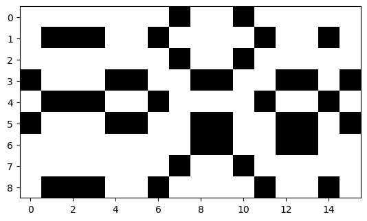

```python
from matplotlib import pyplot as plt

c = plt.imshow(1 - X, cmap='gray')
plt.show()
```

Q8: Ecrire la fonction Reordonner (aide : utiliser argsort() de numpy)

- qui prend en paramètres X,et ses vecteurs singuliers u et v obtenus à partir de svd_1d(X, epsilon=1e-10)
- et qui renvoie la matrice X réordonnée selon le tri de u et v

# Réponse 08

Réordonnement de la matrice $X$:

```python
#%%script false --no-raise-error


def reordonner(X, u, v):
    """
        renvoie les lignes et les colonnes de X réorganisées  par rapport au tri des vecteurs  u et v
        utiliser argsort() pour trier les vecteurs u et v
    """

    row_indices = np.argsort(u)
    column_indices = np.argsort(v)
    X_reordonnee = X[row_indices]
    X_reordonnee = X_reordonnee[:, column_indices]
    return X_reordonnee
```

Q9:

- Claculer les deux premiers vecteurs singuliers de X u et v - (appeler la fonction R1svd)
- Réordonner X en fonction des tri de u et v- (appler la fonction Reordonner)
- Visualiser X réordnnée (avec imshow) pour avoir une matrice réorganiser par blocs
- Résultat attendu

[figure not shown]

# Réponse 09

Visualisation de la matrice $X$ réordonnée selon le tri de $u$ et $v$:  
**Remarque:** l'ordre des groupes dépend de l'initialisation de $u$ dans R1SVD.

```
erreur =  0.09477018678728262
erreur =  0.015892537959825516
erreur =  0.0026507153208380043
erreur =  0.00044183674576629825
erreur =  7.364085384916944e-05
erreur =  1.227351434897796e-05
erreur =  2.0455867996568516e-06
erreur =  3.409311630986237e-07
erreur =  5.6821861360905826e-08
erreur =  9.470310230585368e-09
erreur =  1.5783850385278677e-09
erreur =  2.6306421270958375e-10
erreur =  4.384396493837881e-11
converged in 14 iterations!
```

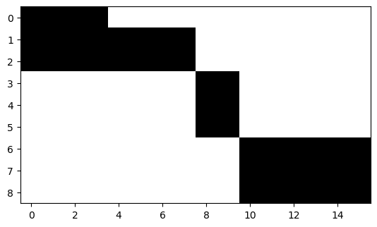

```python
Dr = np.diag(np.sum(X, axis=1))
Dc = np.diag(np.sum(X, axis=0))
u, v = r1svd(X, Dr, Dc)
X_reordonnee = reordonner(X, u, v)
c = plt.imshow(1 - X_reordonnee, cmap='gray')
plt.show()
```

Q10:

- Calculer la matrice de similarité entre les lignes de X, $SR=XX^T$, ($X^T$ est matrice transposée de X).
- Calculer la matrice de similarité entre les colonnes de X, $SC=X^TX$
- Construire la matrice $M= \begin{pmatrix} SR & X\\ X^T & SC \end{pmatrix}$
- Visualiser M reordonnée en fonction des tris de u et v.
- Résultat attendu

[figure not shown]

# Réponse 10

Visualisation de la matrice $M$:

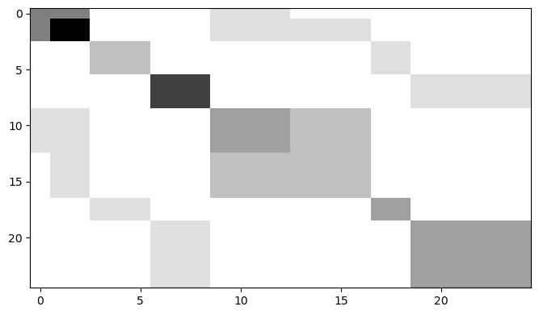

```python
X = X_reordonnee.copy()
SR = X@X.T
SC = X.T@X

M = np.block([[SR, X], [X.T, SC]])

plt.figure(figsize = (8,4.5))
c = plt.imshow(1 - M, cmap='gray', aspect='auto')
plt.show()
```

Q11: Tracer le deux vecteurs u et v triés? qu'en conluez vous?

# **Réponse 11**

## **Conclusion:**

L'algorithme "Rank one SVD for nonnegative data visualization" nous a permet de découvrire trois groupes principals des villes:

- **Les villages reculés** {A, E, F, I, J, M, N, P} : se sont des villages caractérisées par une manque des nécessités de la vie (pas de médecins, l'école à une salle), il y a meme des villes {I, J, M, N} qui n'ont pas d'approvisionnement en eau.
- **Les villages rurales** {B, C, D, G, L, O}: se sont des villes caractérisées par les activités agricoles d'ou on remarque la présence des coopératives agricoles et du vétérinaire.
- **Les villes** {H, K}: disposent de plus de services par rapport aux autres comme les lycées, d'une station de police et la gare de train.

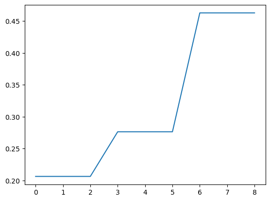

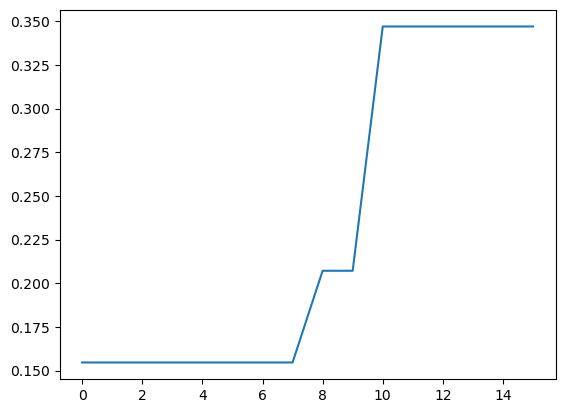

|  | I | J | M | N | A | E | F | P | H | K | B | C | D | G | L | O |
| --- | --- | --- | --- | --- | --- | --- | --- | --- | --- | --- | --- | --- | --- | --- | --- | --- |
| NoWaterSupply | 1 | 1 | 1 | 1 | 0 | 0 | 0 | 0 | 0 | 0 | 0 | 0 | 0 | 0 | 0 | 0 |
| OneRoomSchool | 1 | 1 | 1 | 1 | 1 | 1 | 1 | 1 | 0 | 0 | 0 | 0 | 0 | 0 | 0 | 0 |
| NoDoctor | 1 | 1 | 1 | 1 | 1 | 1 | 1 | 1 | 0 | 0 | 0 | 0 | 0 | 0 | 0 | 0 |
| HighSchool | 0 | 0 | 0 | 0 | 0 | 0 | 0 | 0 | 1 | 1 | 0 | 0 | 0 | 0 | 0 | 0 |
| Railstation | 0 | 0 | 0 | 0 | 0 | 0 | 0 | 0 | 1 | 1 | 0 | 0 | 0 | 0 | 0 | 0 |
| PoliceStation | 0 | 0 | 0 | 0 | 0 | 0 | 0 | 0 | 1 | 1 | 0 | 0 | 0 | 0 | 0 | 0 |
| AgricultCoop | 0 | 0 | 0 | 0 | 0 | 0 | 0 | 0 | 0 | 0 | 1 | 1 | 1 | 1 | 1 | 1 |
| Veterinary | 0 | 0 | 0 | 0 | 0 | 0 | 0 | 0 | 0 | 0 | 1 | 1 | 1 | 1 | 1 | 1 |
| LandReallocation | 0 | 0 | 0 | 0 | 0 | 0 | 0 | 0 | 0 | 0 | 1 | 1 | 1 | 1 | 1 | 1 |

```python
villes_ind = np.argsort(u)
u_trie = np.sort(u)
chara_ind = np.argsort(v)
v_trie = np.sort(v)

plt.plot(u_trie)
plt.show()
plt.plot(v_trie)
plt.show()

cols = X_df.columns.tolist()
cols = [cols[i] for i in chara_ind]
rows = X_df.index.tolist()
rows = [rows[i] for i in villes_ind]

X_df = X_df.reindex(index=rows, columns=cols)


def color_cells(val):
    color = 'background-color: #FFFF00' if val == 1 else 'background-color: #55FFFF'
    return color


X_df = X_df.style.applymap(color_cells)



X_df
```

## Partie 2 : Comparaison des méthodes d'optimisation

L'objectif de cette partie est de comparer différentes méthodes d'optimisation basées sur la descente de gradient ainsi que la méthode de Newton pour minimiser une fonction de coût, comme la régression logistique, sur un ensemble de données. Le projet consisterait à :

- Implémenter différentes variantes de la descente de gradient et Newton, telles que :
  - Descente de gradient standard (Batch Gradient Descent, BGD)
  - Descente de gradient stochastique (Stochastic Gradient Descent, SGD)
  - Descente de gradient par mini-lots (Mini-Batch Gradient Descent)
  - Descente de gradient avec momentum
  - Newton
- Comparaison des Méthodes Comparer les performances des différentes méthodes d'optimisation sur les mêmes jeux de données (2 jeux dofférents). Les critères de comparaison peuvent inclure :
  - Le nombre d'itérations nécessaires pour atteindre la convergence.
  - Le coût final atteint par la fonction de coût.
  - La précision finale sur l'ensemble de test.
- Analyse de la Sensibilité aux Hyperparamètres
  - Taux d'Apprentissage : Étudiez l'impact de différents taux d'apprentissage sur la vitesse de convergence et la qualité de la solution obtenue.
  - Taille du Mini-Lot (pour Mini-Batch GD) : Testez différentes tailles de mini-lots pour voir leur effet sur la stabilité des mises à jour et la convergence.
  - Facteurs de Momentum (β pour Momentum) : Analysez comment les valeurs de ces hyperparamètres affectent les performances.

```python
import time
import numpy as np
import pandas as pd
import seaborn as sns
import matplotlib.pyplot as plt
from tqdm import tqdm
import requests
from io import BytesIO
from zipfile import ZipFile
from tabulate import tabulate
from sklearn.datasets import make_classification
from sklearn.model_selection import train_test_split
from sklearn.preprocessing import StandardScaler
from sklearn.preprocessing import LabelEncoder
from sklearn.metrics import log_loss
```

### Helper Functions

```python
# Fonction sigmoïde
def sigmoid(z):
    return 1 / (1 + np.exp(-z))

# Fonction de coût pour la régression logistique
def compute_cost(X, y, theta):
    m = len(y)
    h = sigmoid(X.dot(theta))
    epsilon = 1e-5  # Pour éviter log(0)
    cost = (1/m) * (-y.T.dot(np.log(h + epsilon)) - (1 - y).T.dot(np.log(1 - h + epsilon)))
    return cost[0][0]

# Fonction pour calculer le gradient
def compute_gradient(X, y, theta):
    m = len(y)
    h = sigmoid(X.dot(theta))
    gradient = (1/m) * X.T.dot(h - y)
    return gradient

# Fonction de coût logistique
def logistic_cost(X, y, theta):
    m = len(y)
    predictions = sigmoid(X.dot(theta))
    epsilon = 1e-5  # Pour éviter log(0)
    cost = (1/m) * (-y.T.dot(np.log(predictions + epsilon)) - (1 - y).T.dot(np.log(1 - predictions + epsilon)))
    return cost[0][0]

# Gradient de la fonction de coût
def logistic_gradient(X, y, theta):
    m = len(y)
    predictions = sigmoid(X.dot(theta))
    gradient = (1/m) * X.T.dot(predictions - y)
    return gradient

# Calcul de la matrice Hessienne
def logistic_hessian(X, theta):
    m, n = X.shape
    predictions = sigmoid(X.dot(theta))
    R = np.diag((predictions * (1 - predictions)).flatten())
    H = (1/m) * X.T.dot(R).dot(X)
    return H
```

### Classe des méthodes d'optimisation

Inclus:

- Descente de gradient par batch
- Descente de gradient stochastique
- Descente de gradient par mini-batch
- Descente de gradient avec momentum
- Descente de Nesterov
- Descente de Newton
- AdaGrad
- RMSProp
- Adam
- AdamW

```python
class GradientDescentVariants:
    def __init__(self, X, y, learning_rate=0.01, iterations=1000, batch_size=None, momentum=0.9, beta1=0.9, beta2=0.999, epsilon=1e-8, convergence_tolerance=1e-4, patience=10, weight_decay=0.01):
        self.X = X
        self.y = y
        self.learning_rate = learning_rate
        self.iterations = iterations
        self.batch_size = batch_size
        self.momentum = momentum
        self.beta1 = beta1
        self.beta2 = beta2
        self.epsilon = epsilon
        self.theta = np.zeros((X.shape[1], 1))
        self.convergence_tolerance = convergence_tolerance
        self.patience = patience
        self.weight_decay = weight_decay

    def batch_gradient_descent(self):
        """Descente de Gradient Standard"""
        cost_history = []
        theta = self.theta.copy()
        start_time = time.time()
        no_improve_steps = 0
        for i in range(self.iterations):
            gradient = compute_gradient(self.X, self.y, theta)
            theta -= self.learning_rate * gradient
            cost = compute_cost(self.X, self.y, theta)
            cost_history.append(cost)
            if len(cost_history) > 1 and abs(cost_history[-2] - cost) < self.convergence_tolerance:
                no_improve_steps += 1
            else:
                no_improve_steps = 0
            if no_improve_steps >= self.patience:
                break
        total_time = time.time() - start_time
        avg_time_per_iter = total_time / (i + 1)
        return theta, cost_history, i + 1, total_time, avg_time_per_iter

    def stochastic_gradient_descent(self):
        """Descente de Gradient Stochastique"""
        cost_history = []
        theta = self.theta.copy()
        start_time = time.time()
        for i in range(self.iterations):
            for j in range(len(self.y)):
                random_index = np.random.randint(0, len(self.y))
                X_i = self.X[random_index, :].reshape(1, -1)
                y_i = self.y[random_index].reshape(1, -1)
                gradient = compute_gradient(X_i, y_i, theta)
                theta -= self.learning_rate * gradient
            cost = compute_cost(self.X, self.y, theta)
            cost_history.append(cost)
            if len(cost_history) > 1 and abs(cost_history[-2] - cost) < self.convergence_tolerance:
                no_improve_steps += 1
            else:
                no_improve_steps = 0
            if no_improve_steps >= self.patience:
                break
        total_time = time.time() - start_time
        avg_time_per_iter = total_time / (i + 1)
        return theta, cost_history, i + 1, total_time, avg_time_per_iter

    def mini_batch_gradient_descent(self):
        """Descente de Gradient par Mini-lots"""
        cost_history = []
        theta = self.theta.copy()
        start_time = time.time()
        no_improve_steps = 0
        for i in range(self.iterations):
            indices = np.random.permutation(len(self.y))
            X_shuffled = self.X[indices]
            y_shuffled = self.y[indices]
            for j in range(0, len(self.y), self.batch_size):
                X_i = X_shuffled[j:j+self.batch_size]
                y_i = y_shuffled[j:j+self.batch_size]
                gradient = compute_gradient(X_i, y_i, theta)
                theta -= self.learning_rate * gradient
            cost = compute_cost(self.X, self.y, theta)
            cost_history.append(cost)
            if len(cost_history) > 1 and abs(cost_history[-2] - cost) < self.convergence_tolerance:
                no_improve_steps += 1
            else:
                no_improve_steps = 0
            if no_improve_steps >= self.patience:
                break
        total_time = time.time() - start_time
        avg_time_per_iter = total_time / (i + 1)
        return theta, cost_history, i + 1, total_time, avg_time_per_iter

    def gradient_descent_with_momentum(self):
        """Descente de Gradient avec Momentum"""
        cost_history = []
        theta = self.theta.copy()
        start_time = time.time()
        no_improve_steps = 0
        v = np.zeros_like(theta)  # Vitesse initiale
        for i in range(self.iterations):
            gradient = compute_gradient(self.X, self.y, theta)
            v = self.momentum * v + self.learning_rate * gradient
            theta -= v
            cost = compute_cost(self.X, self.y, theta)
            cost_history.append(cost)
            if len(cost_history) > 1 and abs(cost_history[-2] - cost) < self.convergence_tolerance:
                no_improve_steps += 1
            else:
                no_improve_steps = 0
            if no_improve_steps >= self.patience:
                break
        total_time = time.time() - start_time
        avg_time_per_iter = total_time / (i + 1)
        return theta, cost_history, i + 1, total_time, avg_time_per_iter

    def nesterov_accelerated_gradient(self):
        """Nesterov Accelerated Gradient"""
        cost_history = []
        theta = self.theta.copy()
        start_time = time.time()
        no_improve_steps = 0
        v = np.zeros_like(theta)
        for i in range(self.iterations):
            temp_theta = theta - self.momentum * v
            gradient = compute_gradient(self.X, self.y, temp_theta)
            v = self.momentum * v + self.learning_rate * gradient
            theta -= v
            cost = compute_cost(self.X, self.y, theta)
            cost_history.append(cost)
            if len(cost_history) > 1 and abs(cost_history[-2] - cost) < self.convergence_tolerance:
                no_improve_steps += 1
            else:
                no_improve_steps = 0
            if no_improve_steps >= self.patience:
                break
        total_time = time.time() - start_time
        avg_time_per_iter = total_time / (i + 1)
        return theta, cost_history, i + 1, total_time, avg_time_per_iter

    def newton_method(self):
        """Méthode de Newton"""
        cost_history = []
        m, n = self.X.shape
        theta = np.zeros((n, 1))
        start_time = time.time()
        no_improve_steps = 0
        lambda_identite = 1e-4 * np.eye(n)
        for i in range(self.iterations):
            gradient = logistic_gradient(self.X, self.y, theta)
            hessian = logistic_hessian(self.X, theta)
            hessian += lambda_identite
            # Mise à jour de theta
            H_inv = np.linalg.inv(hessian)
            theta -= H_inv.dot(gradient)

            # Calcul du coût
            cost = logistic_cost(self.X, self.y, theta)
            cost_history.append(cost)
            if len(cost_history) > 1 and abs(cost_history[-2] - cost) < self.convergence_tolerance:
                no_improve_steps += 1
            else:
                no_improve_steps = 0
            if no_improve_steps >= self.patience:
                break
        total_time = time.time() - start_time
        avg_time_per_iter = total_time / (i + 1)
        return theta, cost_history, i + 1, total_time, avg_time_per_iter

    def adagrad(self):
        """Adagrad"""
        cost_history = []
        theta = self.theta.copy()
        start_time = time.time()
        no_improve_steps = 0
        G = np.zeros_like(theta)
        for i in range(self.iterations):
            gradient = compute_gradient(self.X, self.y, theta)
            G += gradient**2
            adjusted_lr = self.learning_rate / (np.sqrt(G) + self.epsilon)
            theta -= adjusted_lr * gradient
            cost = compute_cost(self.X, self.y, theta)
            cost_history.append(cost)
            if len(cost_history) > 1 and abs(cost_history[-2] - cost) < self.convergence_tolerance:
                no_improve_steps += 1
            else:
                no_improve_steps = 0
            if no_improve_steps >= self.patience:
                break
        total_time = time.time() - start_time
        avg_time_per_iter = total_time / (i + 1)
        return theta, cost_history, i + 1, total_time, avg_time_per_iter

    def rmsprop(self):
        """RMSprop"""
        cost_history = []
        theta = self.theta.copy()
        start_time = time.time()
        no_improve_steps = 0
        E = np.zeros_like(theta)
        for i in range(self.iterations):
            gradient = compute_gradient(self.X, self.y, theta)
            E = self.beta2 * E + (1 - self.beta2) * gradient**2
            adjusted_lr = self.learning_rate / (np.sqrt(E) + self.epsilon)
            theta -= adjusted_lr * gradient
            cost = compute_cost(self.X, self.y, theta)
            cost_history.append(cost)
            if len(cost_history) > 1 and abs(cost_history[-2] - cost) < self.convergence_tolerance:
                no_improve_steps += 1
            else:
                no_improve_steps = 0
            if no_improve_steps >= self.patience:
                break
        total_time = time.time() - start_time
        avg_time_per_iter = total_time / (i + 1)
        return theta, cost_history, i + 1, total_time, avg_time_per_iter

    def adam(self):
        """Adam (Adaptive Moment Estimation)"""
        cost_history = []
        theta = self.theta.copy()
        start_time = time.time()
        no_improve_steps = 0
        m = np.zeros_like(theta)
        v = np.zeros_like(theta)
        for i in range(1, self.iterations + 1):
            gradient = compute_gradient(self.X, self.y, theta)
            m = self.beta1 * m + (1 - self.beta1) * gradient
            v = self.beta2 * v + (1 - self.beta2) * gradient**2
            m_hat = m / (1 - self.beta1**i)
            v_hat = v / (1 - self.beta2**i)
            theta -= self.learning_rate / (np.sqrt(v_hat) + self.epsilon) * m_hat
            cost = compute_cost(self.X, self.y, theta)
            cost_history.append(cost)
            if len(cost_history) > 1 and abs(cost_history[-2] - cost) < self.convergence_tolerance:
                no_improve_steps += 1
            else:
                no_improve_steps = 0
            if no_improve_steps >= self.patience:
                break
        total_time = time.time() - start_time
        avg_time_per_iter = total_time / (i + 1)
        return theta, cost_history, i + 1, total_time, avg_time_per_iter

    def adamw(self):
        """AdamW (Adam with decoupled Weight Decay)"""
        cost_history = []
        theta = self.theta.copy()
        start_time = time.time()
        no_improve_steps = 0
        m = np.zeros_like(theta)
        v = np.zeros_like(theta)
        for i in range(1, self.iterations + 1):
            gradient = compute_gradient(self.X, self.y, theta)
            m = self.beta1 * m + (1 - self.beta1) * gradient
            v = self.beta2 * v + (1 - self.beta2) * gradient**2
            m_hat = m / (1 - self.beta1**i)
            v_hat = v / (1 - self.beta2**i)
            theta -= (self.learning_rate / (np.sqrt(v_hat) + self.epsilon)) * m_hat + self.weight_decay * theta
            cost = compute_cost(self.X, self.y, theta)
            cost_history.append(cost)
            if len(cost_history) > 1 and abs(cost_history[-2] - cost) < self.convergence_tolerance:
                no_improve_steps += 1
            else:
                no_improve_steps = 0
            if no_improve_steps >= self.patience:
                break
        total_time = time.time() - start_time
        avg_time_per_iter = total_time / (i + 1)
        return theta, cost_history, i + 1, total_time, avg_time_per_iter
```

### Téléchargement de datasets

Chargement de 4 datasets comme suit:

```python
def load_uci_sonar():
    # Load Sonar dataset from UCI Repository (or from a local CSV file if downloaded)
    url = 'https://archive.ics.uci.edu/ml/machine-learning-databases/undocumented/connectionist-bench/sonar/sonar.all-data'
    data = pd.read_csv(url, header=None)
    X = data.iloc[:, :-1].values
    y = LabelEncoder().fit_transform(data.iloc[:, -1].values)  # Encode 'R' and 'M' to binary
    return {'data': X, 'target': y}

def load_uci_haberman():
    # Load Haberman dataset from UCI Repository (or from a local CSV file if downloaded)
    url = 'https://archive.ics.uci.edu/ml/machine-learning-databases/haberman/haberman.data'
    data = pd.read_csv(url, header=None)
    X = data.iloc[:, :-1].values
    y = data.iloc[:, -1].values - 1  # Adjust to binary 0/1 for easier training
    return {'data': X, 'target': y}

def load_uci_covertype():
    # Download the Covertype dataset from UCI Repository (this dataset is large)
    url = 'https://archive.ics.uci.edu/ml/machine-learning-databases/covtype/covtype.data.gz'
    data = pd.read_csv(url, header=None)
    data = data.sample(frac=0.05, random_state=42)  # Take only 5% of the data
    X = data.iloc[:, :-1].values
    y = (data.iloc[:, -1].values == 2).astype(int)  # Convert to binary class: only '2' as positive class
    return {'data': X, 'target': y}

def load_mushroom():
    url = 'https://archive.ics.uci.edu/ml/machine-learning-databases/mushroom/agaricus-lepiota.data'
    columns = ['class', 'cap_shape', 'cap_surface', 'cap_color', 'bruises', 'odor',
               'gill_attachment', 'gill_spacing', 'gill_size', 'gill_color',
               'stalk_shape', 'stalk_root', 'stalk_surface_above_ring',
               'stalk_surface_below_ring', 'stalk_color_above_ring',
               'stalk_color_below_ring', 'veil_type', 'veil_color', 'ring_number',
               'ring_type', 'spore_print_color', 'population', 'habitat']
    data = pd.read_csv(url, header=None, names=columns)

    # Separate features and target
    X = data.drop('class', axis=1)
    y = (data['class'] == 'p').astype(int).values  # Binary target: 1 if poisonous, 0 if edible

    # One-hot encode categorical features
    X = pd.get_dummies(X, drop_first=True)

    return {'data': X, 'target': y}
```

### Chargement de dataset

Fonction qui permet de charger le dataset demandé parmis les 4 datasets disponibles.

```python
# Define function to load and preprocess dataset
def load_and_preprocess(dataset_name):
    if dataset_name == 'Sonar':
        data = load_uci_sonar()
    elif dataset_name == 'Haberman':
        data = load_uci_haberman()
    elif dataset_name == 'Covertype':
        data = load_uci_covertype()
    elif dataset_name == 'Mushroom':
        data = load_mushroom()

    X, y = data['data'], data['target']
    y = y.reshape(-1, 1)

    # Normalize data
    scaler = StandardScaler()
    X = scaler.fit_transform(X)

    # Train-test split
    X_train, X_test, y_train, y_test = train_test_split(X, y, test_size=0.2, random_state=42)
    return X_train, X_test, y_train, y_test
```

### Comparaison des méthodes d'optimisation sur différents jeux de données

#### Helper Functions

Fonctions pour mieux visualiser les résultats.

```python
def highlight_top_and_bottom(values):
    """Highlights the best, second best, third best, and worst values with different pale colors."""
    sorted_indices = np.argsort(values)  # Sort values to get indices in ascending order
    highlighted_values = []
    for i, value in enumerate(values):
        if i == sorted_indices[0]:  # Best value (1st place, pale green)
            highlighted_values.append(f"\033[48;2;200;255;200m{value:.6f}\033[0m")  # Pale green
        elif i == sorted_indices[1]:  # 2nd place (pale yellow)
            highlighted_values.append(f"\033[48;2;247;247;200m{value:.6f}\033[0m")  # Pale yellow
        elif i == sorted_indices[2]:  # 3rd place (pale orange)
            highlighted_values.append(f"\033[48;2;255;218;185m{value:.6f}\033[0m")  # Pale orange
        elif i == sorted_indices[-1]:  # Worst value (pale red)
            highlighted_values.append(f"\033[48;2;255;182;193m{value:.6f}\033[0m")  # Pale red
        else:
            highlighted_values.append(f"{value:.6f}")  # No color for other values
    return highlighted_values
```

#### Fonction de test principale

```python
from tabulate import tabulate
from tqdm import tqdm
import matplotlib.pyplot as plt
import numpy as np

def test_optimization_methods(X_train, y_train, X_test, y_test):
    gd_variants = GradientDescentVariants(X_train, y_train, learning_rate=0.01, iterations=500, batch_size=32)
    methods = {
        'Batch Gradient Descent': gd_variants.batch_gradient_descent,
        'Stochastic Gradient Descent': gd_variants.stochastic_gradient_descent,
        'Mini-Batch Gradient Descent': gd_variants.mini_batch_gradient_descent,
        'Momentum': gd_variants.gradient_descent_with_momentum,
        'Nesterov': gd_variants.nesterov_accelerated_gradient,
        'Newton': gd_variants.newton_method,
        'Adagrad': gd_variants.adagrad,
        'RMSprop': gd_variants.rmsprop,
        'Adam': gd_variants.adam,
        'AdamW': gd_variants.adamw
    }

    plt.figure(figsize=(14, 8))
    results = []

    for name, method in tqdm(methods.items(), desc="Testing Optimization Methods"):
        theta, cost_history, iterations, total_time, avg_time_per_iter = method()

        # Final training and test costs
        final_train_cost = logistic_cost(X_train, y_train, theta)
        final_test_cost = logistic_cost(X_test, y_test, theta)

        plt.plot(cost_history, label=name)
        results.append([name, iterations, total_time, avg_time_per_iter, final_train_cost, final_test_cost])

    plt.xlabel('Iterations')
    plt.ylabel('Cost')
    plt.title('Comparison of Gradient Descent Variants')
    plt.legend()
    plt.show()

    # Extract columns for highlighting top and bottom values
    iterations_col = [row[1] for row in results]
    total_time_col = [row[2] for row in results]
    avg_time_per_iter_col = [row[3] for row in results]
    final_train_cost_col = [row[4] for row in results]
    final_test_cost_col = [row[5] for row in results]

    # Apply top and bottom color highlighting for each column
    highlighted_iterations = highlight_top_and_bottom(iterations_col)
    highlighted_total_time = highlight_top_and_bottom(total_time_col)
    highlighted_avg_time = highlight_top_and_bottom(avg_time_per_iter_col)
    highlighted_final_train_cost = highlight_top_and_bottom(final_train_cost_col)
    highlighted_final_test_cost = highlight_top_and_bottom(final_test_cost_col)

    # Re-assemble results with highlighted values
    highlighted_results = []
    for i, row in enumerate(results):
        highlighted_results.append([
            row[0],                        # Method name
            highlighted_iterations[i],     # Iterations with color
            highlighted_total_time[i],     # Total time with color
            highlighted_avg_time[i],       # Avg time per iteration with color
            highlighted_final_train_cost[i],  # Final train cost with color
            highlighted_final_test_cost[i]    # Final test cost with color
        ])

    # Display the results in a table
    headers = ["Method", "Iterations", "Total Time (s)", "Avg Time/Iter (s)", "Final Train Cost", "Final Test Cost"]
    print("\n\n", tabulate(highlighted_results, headers=headers, tablefmt="grid"))
```

#### Test sur un dataset 'Low Samples, Low Features'

```
Testing optimization methods on Haberman dataset...
```

[figure not shown]

[output not shown]

```python
print(f"\nTesting optimization methods on Haberman dataset...")
X_train, X_test, y_train, y_test = load_and_preprocess("Haberman")
test_optimization_methods(X_train, y_train, X_test, y_test)
```

Pour un dataset avec peu d'exemples et peu de caractéristiques, on peut voir que toutes les méthodes s'en sortent assez bien, à l'exception de la **descente de gradient stochastique** qui prend beaucoup trop de temps comparé au reste des méthodes.

Les meilleurs scores en termes de **coût final d'entraînement** sont atteints par la **méthode de Newton** et **RMSprop**, avec des coûts de 0,638133 et 0,638138 respectivement. Cependant, en regardant le **coût final sur le jeu de test**, la **descente de gradient par batch complet** obtient le meilleur résultat avec un coût de 0,687284, suivie de près par **Adagrad** et **AdamW**.

Globalement, les autres méthodes se retrouvent assez proches en termes de résultats, sauf la **descente de gradient stochastique** qui, comme mentionné précédemment, **ne converge jamais** et prend beaucoup plus de temps. **Adagrad** et la **descente de gradient par batch complet** ont des coûts finaux légèrement plus élevés sur l'ensemble d'entraînement, mais performent mieux sur le jeu de test.

> Pour ce dataset, bien que la méthode de Newton offre une bonne approche en termes de convergence rapide, la **descente de gradient par batch complet** pourrait être préférable en raison de sa meilleure performance sur le jeu de test. Cependant, pour un compromis entre rapidité et performance, **Adagrad** reste une excellente option.

#### Test sur un dataset 'Low Samples, High Features'

```
Testing optimization methods on Sonar dataset...
```

[figure not shown]

[output not shown]

```python
print(f"\nTesting optimization methods on Sonar dataset...")
X_train, X_test, y_train, y_test = load_and_preprocess("Sonar")
test_optimization_methods(X_train, y_train, X_test, y_test)
```

Pour ce dataset avec peu d'exemples mais beaucoup de caractéristiques, on constate que la **méthode de Newton** atteint le **plus faible nombre d'itérations** et le **meilleur coût final sur l'ensemble d'entraînement** avec un coût de 0,001118. Cependant, son **coût final sur le jeu de test** est de 2,28972, ce qui indique un surapprentissage important et une généralisation médiocre.

La **descente de gradient par batch complet** présente le **coût final sur le test** le plus bas à 0,395135, suivie de près par **Adagrad**, **Mini-Batch Gradient Descent** et **AdamW**, qui ont tous des coûts finaux sur le test autour de 0,4.

Les méthodes comme la **descente de gradient stochastique** et **RMSprop** obtiennent de bons coûts sur l'ensemble d'entraînement mais présentent des **coûts finaux sur le test** élevés, respectivement 0,937667 et 0,960824, indiquant également un surapprentissage.

En termes de temps, **AdamW** se distingue avec un temps total de 0,032298 seconde pour 293 itérations, offrant un bon compromis entre rapidité et performance sur le jeu de test.

En effet, sur un dataset avec peu d'exemples et beaucoup de caractéristiques le sur-apprentissage devient un réel défi. La plupart des méthodes auront tendence à tomber dans ce vis. La **descente de gradient par batch complet** permet d'avoir plus de données à chaque passage et donc d'éviter un peu ce piège comme les méthodes qui adaptent le taux d'apprentissages comme **Adagrad** ou qui implémentent du weight decay comme **AdamW** pour éviter ce phénomonène.

> Pour ce dataset, bien que la méthode de Newton converge rapidement sur l'ensemble d'entraînement, elle ne généralise pas bien. La **descente de gradient par batch complet** ou **Adagrad** s'avèrent être de meilleures approches en termes de performance sur le jeu de test.

#### Test sur un dataset 'High Samples, High Features'

```
Testing optimization methods on Covertype dataset...
```

[figure not shown]

[output not shown]

```python
print(f"\nTesting optimization methods on Covertype dataset...")
X_train, X_test, y_train, y_test = load_and_preprocess("Covertype")
test_optimization_methods(X_train, y_train, X_test, y_test)
```

Dans ce dataset, même avec seulement 5% du dataset Covertype, nous commençons à constater les problèmes de la **descente de gradient stochastique**, cette approche a pris 286,404 secondes, contrairement à **RMSprop** qui a pris seulement 0,102255 seconde. **RMSprop** a donc été environ 2 800 fois plus rapide.

La **méthode de Newton** atteint le meilleur **coût final** sur les ensembles d'entraînement et de test, avec des coûts de 0,509686 et 0,515049 respectivement. Cependant, cela s'est fait au prix d'un temps de calcul très élevé de 42,6609 secondes, soit 417 fois plus lent que **RMSprop**, qui présente un **coût final sur le test** légèrement supérieur de seulement 0,002341, ce qui est négligeable en comparaison avec le temps gagné.

La **descente de gradient par mini-batch** offre également de bonnes performances en termes de **coût final**, avec des valeurs proches de celles de RMSprop, mais avec un temps total plus élevé de 0,596097 seconde.

On peut également remarquer que la **descente de gradient par batch complet** a du mal à converger dû au nombre important de données qui rendent ses mises à jour moins significatives.

#### Test sur un dataset 'High Samples, Low Features'

```
Testing optimization methods on Mushroom dataset...
```

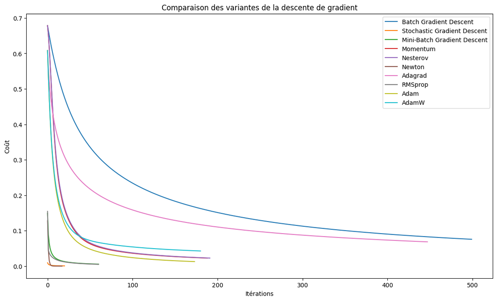

```
 +-----------------------------+--------------+-------------------+-----------------------------+----------------------+---------------------+
| Méthode                     |   Itérations |   Temps total (s) |   Temps moyen/itération (s) |   Coût final (train) |   Coût final (test) |
+=============================+==============+===================+=============================+======================+=====================+
| Batch Gradient Descent      |          500 |          0.819064 |                    0.001638 |             0.075638 |            0.080228 |
+-----------------------------+--------------+-------------------+-----------------------------+----------------------+---------------------+
| Stochastic Gradient Descent |           21 |          3.88373  |                    0.184939 |             0.000582 |            0.000668 |
+-----------------------------+--------------+-------------------+-----------------------------+----------------------+---------------------+
| Mini-Batch Gradient Descent |           61 |          0.370937 |                    0.006081 |             0.005607 |            0.005483 |
+-----------------------------+--------------+-------------------+-----------------------------+----------------------+---------------------+
| Momentum                    |          189 |          0.175754 |                    0.00093  |             0.022575 |            0.024332 |
+-----------------------------+--------------+-------------------+-----------------------------+----------------------+---------------------+
| Nesterov                    |          192 |          0.208656 |                    0.001087 |             0.022679 |            0.024423 |
+-----------------------------+--------------+-------------------+-----------------------------+----------------------+---------------------+
| Newton                      |           18 |          3.72604  |                    0.207002 |            -2e-06    |           -1e-06    |
+-----------------------------+--------------+-------------------+-----------------------------+----------------------+---------------------+
| Adagrad                     |          448 |          0.444875 |                    0.000993 |             0.068435 |            0.075007 |
+-----------------------------+--------------+-------------------+-----------------------------+----------------------+---------------------+
| RMSprop                     |           61 |          0.051566 |                    0.000845 |             0.004964 |            0.005352 |
+-----------------------------+--------------+-------------------+-----------------------------+----------------------+---------------------+
| Adam                        |          175 |          0.168262 |                    0.000961 |             0.012721 |            0.014138 |
+-----------------------------+--------------+-------------------+-----------------------------+----------------------+---------------------+
| AdamW                       |          182 |          0.1476   |                    0.000811 |             0.042648 |            0.04616  |
+-----------------------------+--------------+-------------------+-----------------------------+----------------------+---------------------+
```

```python
print(f"\nTesting optimization methods on Mushroom dataset...")
X_train, X_test, y_train, y_test = load_and_preprocess("Mushroom")
test_optimization_methods(X_train, y_train, X_test, y_test)
```

Pour ce dataset, nous observons que la **méthode de Newton** atteint le **meilleur coût final** sur les ensembles d'entraînement et de test, avec des valeurs proches de zéro. Cependant, cela se fait au prix d'un temps de calcul élevé de 3,72604 secondes pour seulement 18 itérations, soit un temps moyen par itération de 0,207002 seconde.

La **descente de gradient stochastique** obtient également un excellent **coût final**, proche de celui de Newton, mais reste lente avec un temps total de 3,88373 secondes pour 21 itérations.

En revanche, **RMSprop** se distingue par son efficacité. Avec un temps total de seulement 0,051566 seconde pour 61 itérations, elle atteint un **coût final** de 0,004964 sur l'ensemble d'entraînement et 0,005352 sur le jeu de test, ce qui est très proche des meilleures performances.

La **descente de gradient par mini-batch** offre des résultats similaires en termes de **coût final**, mais avec un temps total plus élevé de 0,370937 seconde.

Les méthodes utilisant le **momentum**, comme **Momentum** et **Nesterov**, présentent des **coûts finaux** plus élevés (environ 0,022) et ne parviennent pas à rivaliser avec les performances de RMSprop en termes de rapidité et d'efficacité.

La **descente de gradient par batch complet** et **Adagrad** affichent des **coûts finaux** relativement élevés, indiquant une convergence moins efficace pour ce dataset.

> Pour ce dataset, bien que la méthode de Newton offre le meilleur coût final, **RMSprop** s'impose comme la meilleure approche en combinant rapidité et performance, faisant d'elle le choix le plus judicieux.

### Analyse de sensibilité aux Hyperparamètres

```python
# Define the methods and their key hyperparameters
methods_and_params = {
    'Batch Gradient Descent': {
        'method': 'batch_gradient_descent',
        'hyperparams': {
            'learning_rate': [0.0001, 0.001, 0.01, 0.1]
        }
    },
    'Stochastic Gradient Descent': {
        'method': 'stochastic_gradient_descent',
        'hyperparams': {
            'learning_rate': [0.0001, 0.001, 0.01, 0.1]
        }
    },
    'Mini-Batch Gradient Descent': {
        'method': 'mini_batch_gradient_descent',
        'hyperparams': {
            'learning_rate': [0.0001, 0.001, 0.01, 0.1],
            'batch_size': [16, 32, 64, 128]
        }
    },
    'Momentum': {
        'method': 'gradient_descent_with_momentum',
        'hyperparams': {
            'learning_rate': [0.0001, 0.001, 0.01, 0.1],
            'momentum': [0.0, 0.5, 0.9, 0.99]
        }
    },
    'Nesterov': {
        'method': 'nesterov_accelerated_gradient',
        'hyperparams': {
            'learning_rate': [0.0001, 0.001, 0.01, 0.1],
            'momentum': [0.0, 0.5, 0.9, 0.99]
        }
    },
    'Newton': {
        'method': 'newton_method',
        'hyperparams': {
            # Newton's method does not use learning rate
        }
    },
    'Adagrad': {
        'method': 'adagrad',
        'hyperparams': {
            'learning_rate': [0.001, 0.01, 0.1, 1]
        }
    },
    'RMSprop': {
        'method': 'rmsprop',
        'hyperparams': {
            'learning_rate': [0.0001, 0.001, 0.01, 0.1],
            'beta2': [0.9, 0.99, 0.999]
        }
    },
    'Adam': {
        'method': 'adam',
        'hyperparams': {
            'learning_rate': [0.0001, 0.001, 0.01, 0.1],
            'beta1': [0.9, 0.99],
            'beta2': [0.9, 0.99, 0.999]
        }
    },
    'AdamW': {
        'method': 'adamw',
        'hyperparams': {
            'learning_rate': [0.0001, 0.001, 0.01, 0.1],
            'beta1': [0.9, 0.99],
            'beta2': [0.9, 0.99, 0.999],
            'weight_decay': [0.0, 0.001, 0.01]
        }
    }
}
```

```python
# Function to test methods with hyperparameters
def test_methods_with_hyperparams(X_train, y_train, X_test, y_test, methods_and_params, iterations=100):
    all_results = []

    for method_name, method_info in methods_and_params.items():
        print(f"\nTesting {method_name} with various hyperparameters...")
        method_func_name = method_info['method']
        hyperparams = method_info.get('hyperparams', {})

        # Generate all combinations of hyperparameters
        import itertools
        param_names = list(hyperparams.keys())
        param_values = list(hyperparams.values())

        # If no hyperparameters (e.g., Newton), use default values
        if not param_names:
            gd_variants = GradientDescentVariants(
                X_train, y_train, iterations=5000, convergence_tolerance=1e-6, patience=20
            )
            method_func = getattr(gd_variants, method_func_name)
            theta, cost_history, iterations, total_time, avg_time_per_iter = method_func()

            # Calculate final train and test costs
            final_train_cost = logistic_cost(X_train, y_train, theta)
            final_test_cost = logistic_cost(X_test, y_test, theta)

            all_results.append({
                'Method': method_name,
                'Hyperparameters': 'Default',
                'Iterations': iterations,
                'Total Time (s)': total_time,
                'Avg Time/Iter (s)': avg_time_per_iter,
                'Final Train Cost': final_train_cost,
                'Final Test Cost': final_test_cost
            })
            continue

        # Generate all combinations of hyperparameter values
        param_combinations = list(itertools.product(*param_values))

        for param_combo in param_combinations:
            # Create a dictionary of the current hyperparameters
            current_params = dict(zip(param_names, param_combo))

            # Initialize the optimizer with current hyperparameters
            gd_variants_params = {
                'X': X_train,
                'y': y_train,
                'iterations': iterations,
                'convergence_tolerance': 1e-6,
                'patience': 20
            }
            for param in current_params:
                gd_variants_params[param] = current_params[param]

            gd_variants = GradientDescentVariants(**gd_variants_params)
            method_func = getattr(gd_variants, method_func_name)

            try:
                theta, cost_history, iterations, total_time, avg_time_per_iter = method_func()

                # Calculate final train and test costs
                final_train_cost = logistic_cost(X_train, y_train, theta)
                final_test_cost = logistic_cost(X_test, y_test, theta)

                # Format hyperparameters for display
                hyperparam_str = ', '.join([f"{k}={v}" for k, v in current_params.items()])
                all_results.append({
                    'Method': method_name,
                    'Hyperparameters': hyperparam_str,
                    'Iterations': iterations,
                    'Total Time (s)': total_time,
                    'Avg Time/Iter (s)': avg_time_per_iter,
                    'Final Train Cost': final_train_cost,
                    'Final Test Cost': final_test_cost
                })
            except Exception as e:
                print(f"Error with {method_name} and hyperparameters {current_params}: {e}")
                continue

    return all_results
```

```python
dataset_name = "Covertype"

print(f"\nTesting optimization methods on {dataset_name} dataset...")
X_train, X_test, y_train, y_test = load_and_preprocess(dataset_name)

# Run the tests
all_results = test_methods_with_hyperparams(X_train, y_train, X_test, y_test, methods_and_params, 500)
# Convert results to DataFrame for better visualization
results_df = pd.DataFrame(all_results)
```

```
Testing optimization methods on Covertype dataset...

Testing Batch Gradient Descent with various hyperparameters...

Testing Stochastic Gradient Descent with various hyperparameters...

Testing Mini-Batch Gradient Descent with various hyperparameters...

Testing Momentum with various hyperparameters...

Testing Nesterov with various hyperparameters...

Testing Newton with various hyperparameters...

Testing Adagrad with various hyperparameters...

Testing RMSprop with various hyperparameters...

Testing Adam with various hyperparameters...

Testing AdamW with various hyperparameters...
```

```python
# Display the results
pd.set_option('display.max_rows', None)
print("\nAll Results:")
display(results_df)
```

```
All Results:
```

|  | Method | Hyperparameters | Iterations | Total Time (s) | Avg Time/Iter (s) | Final Train Cost | Final Test Cost |
| --- | --- | --- | --- | --- | --- | --- | --- |
| 0 | Batch Gradient Descent | learning_rate=0.0001 | 500 | 2.660955 | 0.005322 | 0.688977 | 0.688963 |
| 1 | Batch Gradient Descent | learning_rate=0.001 | 500 | 2.410818 | 0.004822 | 0.658121 | 0.658067 |
| 2 | Batch Gradient Descent | learning_rate=0.01 | 500 | 1.241994 | 0.002484 | 0.563020 | 0.564168 |
| 3 | Batch Gradient Descent | learning_rate=0.1 | 500 | 0.985305 | 0.001971 | 0.515637 | 0.518717 |
| 4 | Stochastic Gradient Descent | learning_rate=0.0001 | 500 | 286.241047 | 0.572482 | 0.512248 | 0.517656 |
| 5 | Stochastic Gradient Descent | learning_rate=0.001 | 500 | 287.942138 | 0.575884 | 0.512868 | 0.517357 |
| 6 | Stochastic Gradient Descent | learning_rate=0.01 | 500 | 289.951409 | 0.579903 | 0.533758 | 0.544597 |
| 7 | Stochastic Gradient Descent | learning_rate=0.1 | 500 | 291.496116 | 0.582992 | 0.828568 | 0.837972 |
| 8 | Mini-Batch Gradient Descent | learning_rate=0.0001, batch_size=16 | 500 | 21.298369 | 0.042597 | 0.513540 | 0.516917 |
| 9 | Mini-Batch Gradient Descent | learning_rate=0.0001, batch_size=32 | 500 | 11.030297 | 0.022061 | 0.518685 | 0.521516 |
| 10 | Mini-Batch Gradient Descent | learning_rate=0.0001, batch_size=64 | 500 | 7.478112 | 0.014956 | 0.529196 | 0.531520 |
| 11 | Mini-Batch Gradient Descent | learning_rate=0.0001, batch_size=128 | 500 | 4.478806 | 0.008958 | 0.544538 | 0.546287 |
| 12 | Mini-Batch Gradient Descent | learning_rate=0.001, batch_size=16 | 500 | 21.392415 | 0.042785 | 0.512189 | 0.517156 |
| 13 | Mini-Batch Gradient Descent | learning_rate=0.001, batch_size=32 | 260 | 5.389951 | 0.020731 | 0.512332 | 0.516523 |
| 14 | Mini-Batch Gradient Descent | learning_rate=0.001, batch_size=64 | 260 | 5.002800 | 0.019242 | 0.512810 | 0.516362 |
| 15 | Mini-Batch Gradient Descent | learning_rate=0.001, batch_size=128 | 260 | 2.288568 | 0.008802 | 0.516087 | 0.519117 |
| 16 | Mini-Batch Gradient Descent | learning_rate=0.01, batch_size=16 | 260 | 11.107940 | 0.042723 | 0.512105 | 0.517153 |
| 17 | Mini-Batch Gradient Descent | learning_rate=0.01, batch_size=32 | 260 | 5.346997 | 0.020565 | 0.512016 | 0.516907 |
| 18 | Mini-Batch Gradient Descent | learning_rate=0.01, batch_size=64 | 260 | 3.381529 | 0.013006 | 0.512179 | 0.517060 |
| 19 | Mini-Batch Gradient Descent | learning_rate=0.01, batch_size=128 | 260 | 4.124716 | 0.015864 | 0.512250 | 0.517167 |
| 20 | Mini-Batch Gradient Descent | learning_rate=0.1, batch_size=16 | 260 | 9.266153 | 0.035639 | 0.528590 | 0.534536 |
| 21 | Mini-Batch Gradient Descent | learning_rate=0.1, batch_size=32 | 260 | 6.856309 | 0.026370 | 0.515535 | 0.520834 |
| 22 | Mini-Batch Gradient Descent | learning_rate=0.1, batch_size=64 | 260 | 3.161432 | 0.012159 | 0.512317 | 0.518933 |
| 23 | Mini-Batch Gradient Descent | learning_rate=0.1, batch_size=128 | 260 | 2.273349 | 0.008744 | 0.512064 | 0.516957 |
| 24 | Momentum | learning_rate=0.0001, momentum=0.0 | 260 | 0.558951 | 0.002150 | 0.690948 | 0.690940 |
| 25 | Momentum | learning_rate=0.0001, momentum=0.5 | 260 | 0.561023 | 0.002158 | 0.688830 | 0.688816 |
| 26 | Momentum | learning_rate=0.0001, momentum=0.9 | 260 | 0.538457 | 0.002071 | 0.673816 | 0.673766 |
| 27 | Momentum | learning_rate=0.0001, momentum=0.99 | 260 | 0.963555 | 0.003706 | 0.604460 | 0.604499 |
| 28 | Momentum | learning_rate=0.001, momentum=0.0 | 260 | 0.936640 | 0.003602 | 0.673251 | 0.673202 |
| 29 | Momentum | learning_rate=0.001, momentum=0.5 | 260 | 1.172102 | 0.004508 | 0.657064 | 0.657009 |

[output cut: 139 more lines]

```
Results for Batch Gradient Descent:
```

|  | Method | Hyperparameters | Iterations | Total Time (s) | Avg Time/Iter (s) | Final Train Cost | Final Test Cost |
| --- | --- | --- | --- | --- | --- | --- | --- |
| 0 | Batch Gradient Descent | learning_rate=0.0001 | 500 | 2.660955 | 0.005322 | 0.688977 | 0.688963 |
| 1 | Batch Gradient Descent | learning_rate=0.001 | 500 | 2.410818 | 0.004822 | 0.658121 | 0.658067 |
| 2 | Batch Gradient Descent | learning_rate=0.01 | 500 | 1.241994 | 0.002484 | 0.563020 | 0.564168 |
| 3 | Batch Gradient Descent | learning_rate=0.1 | 500 | 0.985305 | 0.001971 | 0.515637 | 0.518717 |

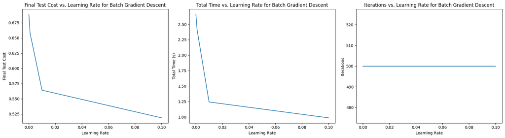

```
Results for Stochastic Gradient Descent:
```

|  | Method | Hyperparameters | Iterations | Total Time (s) | Avg Time/Iter (s) | Final Train Cost | Final Test Cost |
| --- | --- | --- | --- | --- | --- | --- | --- |
| 4 | Stochastic Gradient Descent | learning_rate=0.0001 | 500 | 286.241047 | 0.572482 | 0.512248 | 0.517656 |
| 5 | Stochastic Gradient Descent | learning_rate=0.001 | 500 | 287.942138 | 0.575884 | 0.512868 | 0.517357 |
| 6 | Stochastic Gradient Descent | learning_rate=0.01 | 500 | 289.951409 | 0.579903 | 0.533758 | 0.544597 |
| 7 | Stochastic Gradient Descent | learning_rate=0.1 | 500 | 291.496116 | 0.582992 | 0.828568 | 0.837972 |

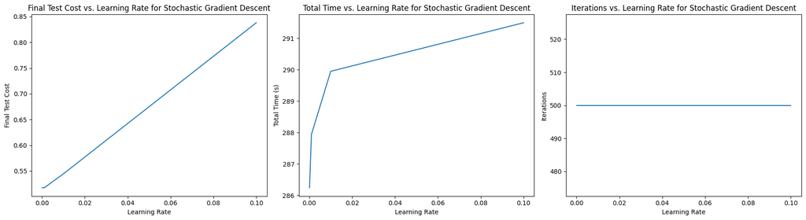

```
Results for Mini-Batch Gradient Descent:
```

|  | Method | Hyperparameters | Iterations | Total Time (s) | Avg Time/Iter (s) | Final Train Cost | Final Test Cost |
| --- | --- | --- | --- | --- | --- | --- | --- |
| 8 | Mini-Batch Gradient Descent | learning_rate=0.0001, batch_size=16 | 500 | 21.298369 | 0.042597 | 0.513540 | 0.516917 |
| 9 | Mini-Batch Gradient Descent | learning_rate=0.0001, batch_size=32 | 500 | 11.030297 | 0.022061 | 0.518685 | 0.521516 |
| 10 | Mini-Batch Gradient Descent | learning_rate=0.0001, batch_size=64 | 500 | 7.478112 | 0.014956 | 0.529196 | 0.531520 |
| 11 | Mini-Batch Gradient Descent | learning_rate=0.0001, batch_size=128 | 500 | 4.478806 | 0.008958 | 0.544538 | 0.546287 |
| 12 | Mini-Batch Gradient Descent | learning_rate=0.001, batch_size=16 | 500 | 21.392415 | 0.042785 | 0.512189 | 0.517156 |
| 13 | Mini-Batch Gradient Descent | learning_rate=0.001, batch_size=32 | 260 | 5.389951 | 0.020731 | 0.512332 | 0.516523 |
| 14 | Mini-Batch Gradient Descent | learning_rate=0.001, batch_size=64 | 260 | 5.002800 | 0.019242 | 0.512810 | 0.516362 |
| 15 | Mini-Batch Gradient Descent | learning_rate=0.001, batch_size=128 | 260 | 2.288568 | 0.008802 | 0.516087 | 0.519117 |
| 16 | Mini-Batch Gradient Descent | learning_rate=0.01, batch_size=16 | 260 | 11.107940 | 0.042723 | 0.512105 | 0.517153 |
| 17 | Mini-Batch Gradient Descent | learning_rate=0.01, batch_size=32 | 260 | 5.346997 | 0.020565 | 0.512016 | 0.516907 |
| 18 | Mini-Batch Gradient Descent | learning_rate=0.01, batch_size=64 | 260 | 3.381529 | 0.013006 | 0.512179 | 0.517060 |
| 19 | Mini-Batch Gradient Descent | learning_rate=0.01, batch_size=128 | 260 | 4.124716 | 0.015864 | 0.512250 | 0.517167 |
| 20 | Mini-Batch Gradient Descent | learning_rate=0.1, batch_size=16 | 260 | 9.266153 | 0.035639 | 0.528590 | 0.534536 |
| 21 | Mini-Batch Gradient Descent | learning_rate=0.1, batch_size=32 | 260 | 6.856309 | 0.026370 | 0.515535 | 0.520834 |
| 22 | Mini-Batch Gradient Descent | learning_rate=0.1, batch_size=64 | 260 | 3.161432 | 0.012159 | 0.512317 | 0.518933 |
| 23 | Mini-Batch Gradient Descent | learning_rate=0.1, batch_size=128 | 260 | 2.273349 | 0.008744 | 0.512064 | 0.516957 |

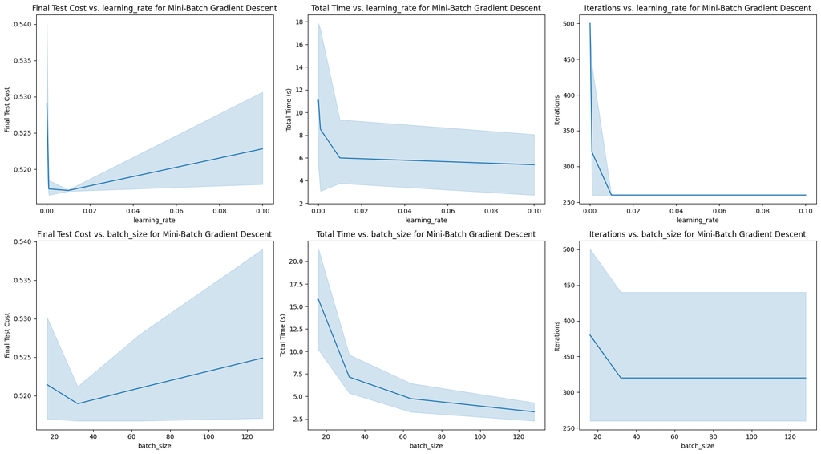

```
Results for Momentum:
```

|  | Method | Hyperparameters | Iterations | Total Time (s) | Avg Time/Iter (s) | Final Train Cost | Final Test Cost |
| --- | --- | --- | --- | --- | --- | --- | --- |
| 24 | Momentum | learning_rate=0.0001, momentum=0.0 | 260 | 0.558951 | 0.002150 | 0.690948 | 0.690940 |
| 25 | Momentum | learning_rate=0.0001, momentum=0.5 | 260 | 0.561023 | 0.002158 | 0.688830 | 0.688816 |
| 26 | Momentum | learning_rate=0.0001, momentum=0.9 | 260 | 0.538457 | 0.002071 | 0.673816 | 0.673766 |
| 27 | Momentum | learning_rate=0.0001, momentum=0.99 | 260 | 0.963555 | 0.003706 | 0.604460 | 0.604499 |
| 28 | Momentum | learning_rate=0.001, momentum=0.0 | 260 | 0.936640 | 0.003602 | 0.673251 | 0.673202 |
| 29 | Momentum | learning_rate=0.001, momentum=0.5 | 260 | 1.172102 | 0.004508 | 0.657064 | 0.657009 |
| 30 | Momentum | learning_rate=0.001, momentum=0.9 | 260 | 0.989016 | 0.003804 | 0.590786 | 0.591259 |
| 31 | Momentum | learning_rate=0.001, momentum=0.99 | 260 | 0.521442 | 0.002006 | 0.530793 | 0.533611 |
| 32 | Momentum | learning_rate=0.01, momentum=0.0 | 260 | 0.498520 | 0.001917 | 0.590216 | 0.590720 |
| 33 | Momentum | learning_rate=0.01, momentum=0.5 | 260 | 0.527390 | 0.002028 | 0.561587 | 0.562777 |
| 34 | Momentum | learning_rate=0.01, momentum=0.9 | 260 | 0.487522 | 0.001875 | 0.523084 | 0.525697 |
| 35 | Momentum | learning_rate=0.01, momentum=0.99 | 260 | 0.513173 | 0.001974 | 0.519932 | 0.527786 |
| 36 | Momentum | learning_rate=0.1, momentum=0.0 | 260 | 0.490155 | 0.001885 | 0.523117 | 0.525707 |
| 37 | Momentum | learning_rate=0.1, momentum=0.5 | 260 | 0.520232 | 0.002001 | 0.515321 | 0.518437 |
| 38 | Momentum | learning_rate=0.1, momentum=0.9 | 166 | 0.338274 | 0.002038 | 0.512322 | 0.516629 |
| 39 | Momentum | learning_rate=0.1, momentum=0.99 | 166 | 0.317410 | 0.001912 | 0.529394 | 0.534146 |

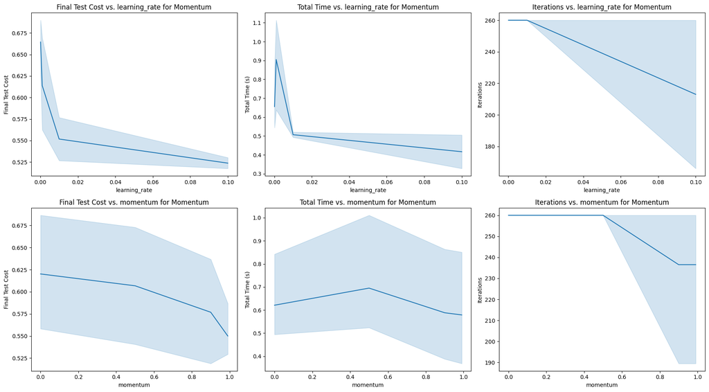

```
Results for Nesterov:
```

|  | Method | Hyperparameters | Iterations | Total Time (s) | Avg Time/Iter (s) | Final Train Cost | Final Test Cost |
| --- | --- | --- | --- | --- | --- | --- | --- |
| 40 | Nesterov | learning_rate=0.0001, momentum=0.0 | 166 | 0.367146 | 0.002212 | 0.691730 | 0.691726 |
| 41 | Nesterov | learning_rate=0.0001, momentum=0.5 | 166 | 0.317292 | 0.001911 | 0.690369 | 0.690359 |
| 42 | Nesterov | learning_rate=0.0001, momentum=0.9 | 166 | 0.341868 | 0.002059 | 0.680603 | 0.680567 |
| 43 | Nesterov | learning_rate=0.0001, momentum=0.99 | 166 | 0.338004 | 0.002036 | 0.636623 | 0.636517 |
| 44 | Nesterov | learning_rate=0.001, momentum=0.0 | 166 | 0.319851 | 0.001927 | 0.679968 | 0.679931 |
| 45 | Nesterov | learning_rate=0.001, momentum=0.5 | 166 | 0.317765 | 0.001914 | 0.668543 | 0.668489 |
| 46 | Nesterov | learning_rate=0.001, momentum=0.9 | 166 | 0.360985 | 0.002175 | 0.612715 | 0.612868 |
| 47 | Nesterov | learning_rate=0.001, momentum=0.99 | 166 | 0.349549 | 0.002106 | 0.541973 | 0.544095 |
| 48 | Nesterov | learning_rate=0.01, momentum=0.0 | 166 | 0.308810 | 0.001860 | 0.611171 | 0.611368 |
| 49 | Nesterov | learning_rate=0.01, momentum=0.5 | 166 | 0.337074 | 0.002031 | 0.579424 | 0.580146 |
| 50 | Nesterov | learning_rate=0.01, momentum=0.9 | 166 | 0.315846 | 0.001903 | 0.530991 | 0.533275 |
| 51 | Nesterov | learning_rate=0.01, momentum=0.99 | 166 | 0.312604 | 0.001883 | 0.535248 | 0.539028 |
| 52 | Nesterov | learning_rate=0.1, momentum=0.0 | 166 | 0.329006 | 0.001982 | 0.530890 | 0.533147 |
| 53 | Nesterov | learning_rate=0.1, momentum=0.5 | 166 | 0.316014 | 0.001904 | 0.519754 | 0.522525 |
| 54 | Nesterov | learning_rate=0.1, momentum=0.9 | 166 | 0.303759 | 0.001830 | 0.512326 | 0.516582 |
| 55 | Nesterov | learning_rate=0.1, momentum=0.99 | 166 | 0.297274 | 0.001791 | 0.517742 | 0.524786 |

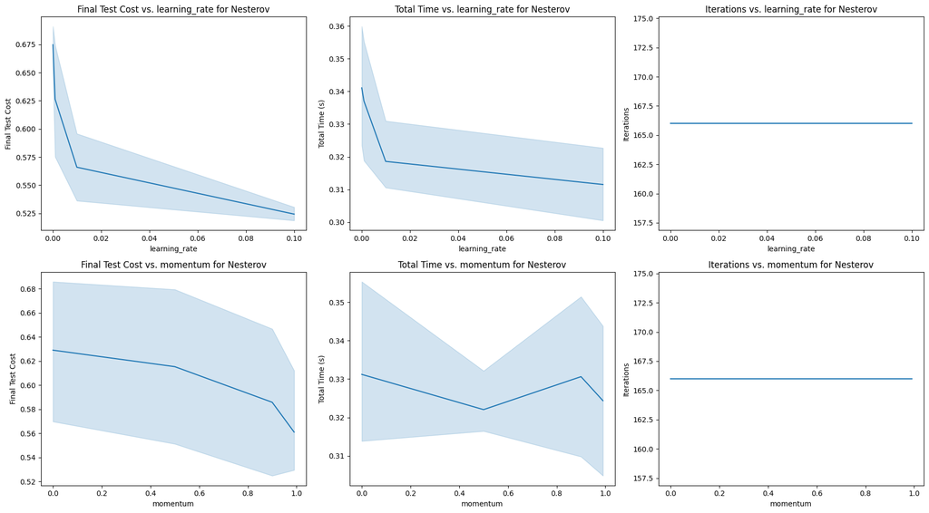

```
Results for Newton:
```

|  | Method | Hyperparameters | Iterations | Total Time (s) | Avg Time/Iter (s) | Final Train Cost | Final Test Cost |
| --- | --- | --- | --- | --- | --- | --- | --- |
| 56 | Newton | Default | 40 | 94.665486 | 2.366637 | 0.509678 | 0.515054 |

```
Newton does not have hyperparameters to tune. Skipping plot.

Results for Adagrad:
```

|  | Method | Hyperparameters | Iterations | Total Time (s) | Avg Time/Iter (s) | Final Train Cost | Final Test Cost |
| --- | --- | --- | --- | --- | --- | --- | --- |
| 57 | Adagrad | learning_rate=0.001 | 40 | 0.085220 | 0.002130 | 0.675959 | 0.675792 |
| 58 | Adagrad | learning_rate=0.01 | 40 | 0.086082 | 0.002152 | 0.596780 | 0.597187 |
| 59 | Adagrad | learning_rate=0.1 | 40 | 0.085304 | 0.002133 | 0.522714 | 0.527297 |
| 60 | Adagrad | learning_rate=1 | 40 | 0.078182 | 0.001955 | 0.517801 | 0.525714 |

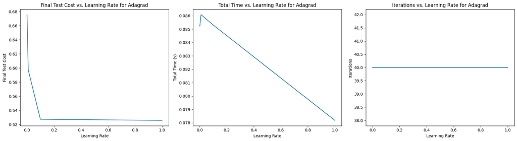

```
Results for RMSprop:
```

|  | Method | Hyperparameters | Iterations | Total Time (s) | Avg Time/Iter (s) | Final Train Cost | Final Test Cost |
| --- | --- | --- | --- | --- | --- | --- | --- |
| 61 | RMSprop | learning_rate=0.0001, beta2=0.9 | 40 | 0.085258 | 0.002131 | 0.685271 | 0.685195 |
| 62 | RMSprop | learning_rate=0.0001, beta2=0.99 | 40 | 0.078967 | 0.001974 | 0.675379 | 0.675208 |
| 63 | RMSprop | learning_rate=0.0001, beta2=0.999 | 40 | 0.081003 | 0.002025 | 0.646964 | 0.646694 |
| 64 | RMSprop | learning_rate=0.001, beta2=0.9 | 40 | 0.080074 | 0.002002 | 0.633606 | 0.633410 |
| 65 | RMSprop | learning_rate=0.001, beta2=0.99 | 40 | 0.080343 | 0.002009 | 0.594882 | 0.595349 |
| 66 | RMSprop | learning_rate=0.001, beta2=0.999 | 40 | 0.104813 | 0.002620 | 0.551437 | 0.554646 |
| 67 | RMSprop | learning_rate=0.01, beta2=0.9 | 40 | 0.078642 | 0.001966 | 0.539468 | 0.543625 |
| 68 | RMSprop | learning_rate=0.01, beta2=0.99 | 40 | 0.077865 | 0.001947 | 0.521756 | 0.526383 |
| 69 | RMSprop | learning_rate=0.01, beta2=0.999 | 40 | 0.077223 | 0.001931 | 0.512185 | 0.517249 |
| 70 | RMSprop | learning_rate=0.1, beta2=0.9 | 40 | 0.081403 | 0.002035 | 0.527243 | 0.536071 |
| 71 | RMSprop | learning_rate=0.1, beta2=0.99 | 40 | 0.079935 | 0.001998 | 0.548200 | 0.558605 |
| 72 | RMSprop | learning_rate=0.1, beta2=0.999 | 40 | 0.079501 | 0.001988 | 0.812705 | 0.790179 |

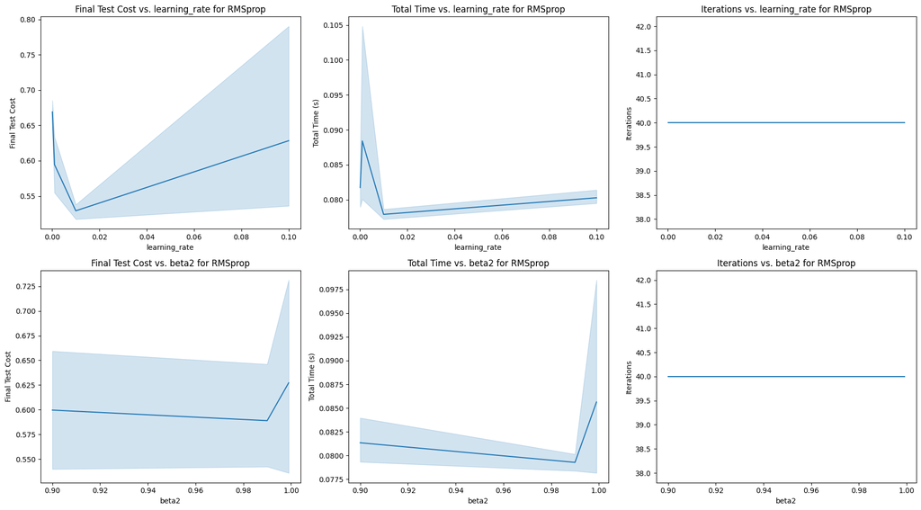

```
Results for Adam:
```

|  | Method | Hyperparameters | Iterations | Total Time (s) | Avg Time/Iter (s) | Final Train Cost | Final Test Cost |
| --- | --- | --- | --- | --- | --- | --- | --- |
| 73 | Adam | learning_rate=0.0001, beta1=0.9, beta2=0.9 | 41 | 0.081810 | 0.001995 | 0.686653 | 0.686591 |
| 74 | Adam | learning_rate=0.0001, beta1=0.9, beta2=0.99 | 42 | 0.078664 | 0.001873 | 0.686521 | 0.686458 |
| 75 | Adam | learning_rate=0.0001, beta1=0.9, beta2=0.999 | 43 | 0.086308 | 0.002007 | 0.686368 | 0.686303 |
| 76 | Adam | learning_rate=0.0001, beta1=0.99, beta2=0.9 | 44 | 0.087349 | 0.001985 | 0.686148 | 0.686088 |
| 77 | Adam | learning_rate=0.0001, beta1=0.99, beta2=0.99 | 45 | 0.083912 | 0.001865 | 0.686021 | 0.685959 |
| 78 | Adam | learning_rate=0.0001, beta1=0.99, beta2=0.999 | 46 | 0.103237 | 0.002244 | 0.685868 | 0.685803 |
| 79 | Adam | learning_rate=0.001, beta1=0.9, beta2=0.9 | 47 | 0.111823 | 0.002379 | 0.634251 | 0.634096 |
| 80 | Adam | learning_rate=0.001, beta1=0.9, beta2=0.99 | 48 | 0.090657 | 0.001889 | 0.635174 | 0.634959 |
| 81 | Adam | learning_rate=0.001, beta1=0.9, beta2=0.999 | 49 | 0.099693 | 0.002035 | 0.634507 | 0.634293 |
| 82 | Adam | learning_rate=0.001, beta1=0.99, beta2=0.9 | 50 | 0.097866 | 0.001957 | 0.629532 | 0.629612 |
| 83 | Adam | learning_rate=0.001, beta1=0.99, beta2=0.99 | 51 | 0.094485 | 0.001853 | 0.630745 | 0.630595 |
| 84 | Adam | learning_rate=0.001, beta1=0.99, beta2=0.999 | 52 | 0.099346 | 0.001910 | 0.630092 | 0.629943 |
| 85 | Adam | learning_rate=0.01, beta1=0.9, beta2=0.9 | 53 | 0.099452 | 0.001876 | 0.534629 | 0.539448 |
| 86 | Adam | learning_rate=0.01, beta1=0.9, beta2=0.99 | 54 | 0.103467 | 0.001916 | 0.538910 | 0.543656 |
| 87 | Adam | learning_rate=0.01, beta1=0.9, beta2=0.999 | 55 | 0.106551 | 0.001937 | 0.538923 | 0.543608 |
| 88 | Adam | learning_rate=0.01, beta1=0.99, beta2=0.9 | 56 | 0.109709 | 0.001959 | 0.556697 | 0.562863 |
| 89 | Adam | learning_rate=0.01, beta1=0.99, beta2=0.99 | 57 | 0.137056 | 0.002404 | 0.548397 | 0.554228 |
| 90 | Adam | learning_rate=0.01, beta1=0.99, beta2=0.999 | 58 | 0.119296 | 0.002057 | 0.547626 | 0.553484 |
| 91 | Adam | learning_rate=0.1, beta1=0.9, beta2=0.9 | 59 | 0.119380 | 0.002023 | 0.510836 | 0.515663 |
| 92 | Adam | learning_rate=0.1, beta1=0.9, beta2=0.99 | 60 | 0.110760 | 0.001846 | 0.511392 | 0.517121 |
| 93 | Adam | learning_rate=0.1, beta1=0.9, beta2=0.999 | 61 | 0.116881 | 0.001916 | 0.511392 | 0.517107 |
| 94 | Adam | learning_rate=0.1, beta1=0.99, beta2=0.9 | 62 | 0.113612 | 0.001832 | 0.541754 | 0.547377 |
| 95 | Adam | learning_rate=0.1, beta1=0.99, beta2=0.99 | 63 | 0.120943 | 0.001920 | 0.531796 | 0.536424 |
| 96 | Adam | learning_rate=0.1, beta1=0.99, beta2=0.999 | 64 | 0.117223 | 0.001832 | 0.530413 | 0.535283 |

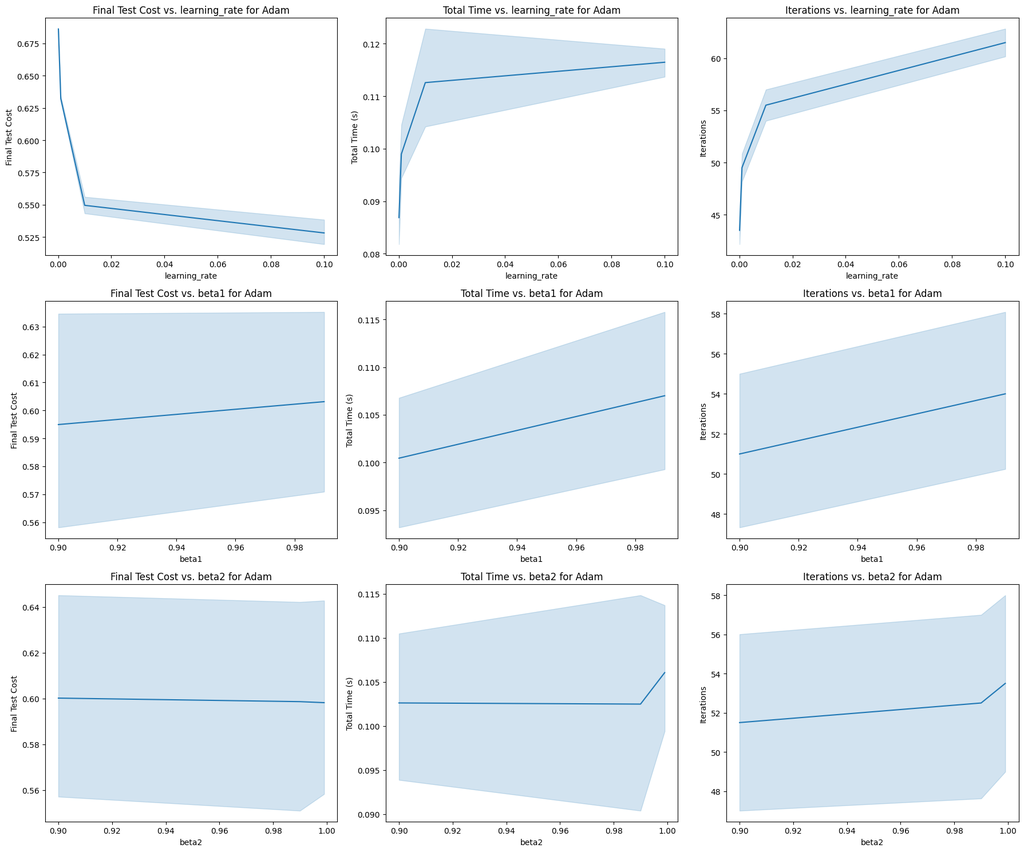

```
Results for AdamW:
```

|  | Method | Hyperparameters | Iterations | Total Time (s) | Avg Time/Iter (s) | Final Train Cost | Final Test Cost |
| --- | --- | --- | --- | --- | --- | --- | --- |
| 97 | AdamW | learning_rate=0.0001, beta1=0.9, beta2=0.9, we... | 65 | 0.143702 | 0.002211 | 0.682904 | 0.682805 |
| 98 | AdamW | learning_rate=0.0001, beta1=0.9, beta2=0.9, we... | 66 | 0.131216 | 0.001988 | 0.683064 | 0.682966 |
| 99 | AdamW | learning_rate=0.0001, beta1=0.9, beta2=0.9, we... | 67 | 0.141665 | 0.002114 | 0.685316 | 0.685240 |
| 100 | AdamW | learning_rate=0.0001, beta1=0.9, beta2=0.99, w... | 68 | 0.143626 | 0.002112 | 0.682532 | 0.682427 |
| 101 | AdamW | learning_rate=0.0001, beta1=0.9, beta2=0.99, w... | 69 | 0.133488 | 0.001935 | 0.682720 | 0.682617 |
| 102 | AdamW | learning_rate=0.0001, beta1=0.9, beta2=0.99, w... | 70 | 0.131013 | 0.001872 | 0.685138 | 0.685059 |
| 103 | AdamW | learning_rate=0.0001, beta1=0.9, beta2=0.999, ... | 71 | 0.159179 | 0.002242 | 0.682095 | 0.681985 |
| 104 | AdamW | learning_rate=0.0001, beta1=0.9, beta2=0.999, ... | 72 | 0.192623 | 0.002675 | 0.682312 | 0.682205 |
| 105 | AdamW | learning_rate=0.0001, beta1=0.9, beta2=0.999, ... | 73 | 0.289501 | 0.003966 | 0.684921 | 0.684839 |
| 106 | AdamW | learning_rate=0.0001, beta1=0.99, beta2=0.9, w... | 74 | 0.312893 | 0.004228 | 0.681411 | 0.681296 |
| 107 | AdamW | learning_rate=0.0001, beta1=0.99, beta2=0.9, w... | 75 | 0.256876 | 0.003425 | 0.681663 | 0.681550 |
| 108 | AdamW | learning_rate=0.0001, beta1=0.99, beta2=0.9, w... | 76 | 0.272173 | 0.003581 | 0.684543 | 0.684459 |
| 109 | AdamW | learning_rate=0.0001, beta1=0.99, beta2=0.99, ... | 77 | 0.255942 | 0.003324 | 0.681068 | 0.680948 |
| 110 | AdamW | learning_rate=0.0001, beta1=0.99, beta2=0.99, ... | 78 | 0.232215 | 0.002977 | 0.681351 | 0.681232 |
| 111 | AdamW | learning_rate=0.0001, beta1=0.99, beta2=0.99, ... | 79 | 0.319781 | 0.004048 | 0.684402 | 0.684314 |
| 112 | AdamW | learning_rate=0.0001, beta1=0.99, beta2=0.999,... | 80 | 0.349608 | 0.004370 | 0.680633 | 0.680508 |
| 113 | AdamW | learning_rate=0.0001, beta1=0.99, beta2=0.999,... | 81 | 0.364192 | 0.004496 | 0.680948 | 0.680826 |
| 114 | AdamW | learning_rate=0.0001, beta1=0.99, beta2=0.999,... | 82 | 0.285407 | 0.003481 | 0.684204 | 0.684114 |
| 115 | AdamW | learning_rate=0.001, beta1=0.9, beta2=0.9, wei... | 83 | 0.318284 | 0.003835 | 0.605996 | 0.606234 |
| 116 | AdamW | learning_rate=0.001, beta1=0.9, beta2=0.9, wei... | 84 | 0.439390 | 0.005231 | 0.607433 | 0.607665 |
| 117 | AdamW | learning_rate=0.001, beta1=0.9, beta2=0.9, wei... | 85 | 0.163933 | 0.001929 | 0.624167 | 0.624272 |
| 118 | AdamW | learning_rate=0.001, beta1=0.9, beta2=0.99, we... | 86 | 0.159661 | 0.001857 | 0.608770 | 0.608851 |
| 119 | AdamW | learning_rate=0.001, beta1=0.9, beta2=0.99, we... | 87 | 0.198417 | 0.002281 | 0.610376 | 0.610429 |
| 120 | AdamW | learning_rate=0.001, beta1=0.9, beta2=0.99, we... | 88 | 0.181691 | 0.002065 | 0.627281 | 0.627114 |
| 121 | AdamW | learning_rate=0.001, beta1=0.9, beta2=0.999, w... | 89 | 0.176647 | 0.001985 | 0.607750 | 0.607852 |
| 122 | AdamW | learning_rate=0.001, beta1=0.9, beta2=0.999, w... | 90 | 0.165471 | 0.001839 | 0.609472 | 0.609544 |
| 123 | AdamW | learning_rate=0.001, beta1=0.9, beta2=0.999, w... | 91 | 0.167534 | 0.001841 | 0.627015 | 0.626851 |
| 124 | AdamW | learning_rate=0.001, beta1=0.99, beta2=0.9, we... | 92 | 0.191163 | 0.002078 | 0.599918 | 0.599728 |
| 125 | AdamW | learning_rate=0.001, beta1=0.99, beta2=0.9, we... | 93 | 0.248954 | 0.002677 | 0.600928 | 0.600749 |
| 126 | AdamW | learning_rate=0.001, beta1=0.99, beta2=0.9, we... | 94 | 0.175207 | 0.001864 | 0.616508 | 0.617190 |
| 127 | AdamW | learning_rate=0.001, beta1=0.99, beta2=0.99, w... | 95 | 0.177946 | 0.001873 | 0.600509 | 0.600902 |
| 128 | AdamW | learning_rate=0.001, beta1=0.99, beta2=0.99, w... | 96 | 0.172626 | 0.001798 | 0.602160 | 0.602496 |
| 129 | AdamW | learning_rate=0.001, beta1=0.99, beta2=0.99, w... | 97 | 0.189128 | 0.001950 | 0.620689 | 0.620632 |
| 130 | AdamW | learning_rate=0.001, beta1=0.99, beta2=0.999, ... | 98 | 0.210766 | 0.002151 | 0.599569 | 0.599960 |
| 131 | AdamW | learning_rate=0.001, beta1=0.99, beta2=0.999, ... | 99 | 0.182970 | 0.001848 | 0.601348 | 0.601680 |
| 132 | AdamW | learning_rate=0.001, beta1=0.99, beta2=0.999, ... | 100 | 0.185776 | 0.001858 | 0.620662 | 0.620584 |
| 133 | AdamW | learning_rate=0.01, beta1=0.9, beta2=0.9, weig... | 101 | 0.185812 | 0.001840 | 0.518104 | 0.523235 |
| 134 | AdamW | learning_rate=0.01, beta1=0.9, beta2=0.9, weig... | 102 | 0.194689 | 0.001909 | 0.518965 | 0.524094 |
| 135 | AdamW | learning_rate=0.01, beta1=0.9, beta2=0.9, weig... | 103 | 0.204031 | 0.001981 | 0.528505 | 0.533670 |
| 136 | AdamW | learning_rate=0.01, beta1=0.9, beta2=0.99, wei... | 104 | 0.223368 | 0.002148 | 0.523283 | 0.528053 |
| 137 | AdamW | learning_rate=0.01, beta1=0.9, beta2=0.99, wei... | 105 | 0.196004 | 0.001867 | 0.524228 | 0.528922 |
| 138 | AdamW | learning_rate=0.01, beta1=0.9, beta2=0.99, wei... | 106 | 0.199697 | 0.001884 | 0.534947 | 0.539101 |
| 139 | AdamW | learning_rate=0.01, beta1=0.9, beta2=0.999, we... | 107 | 0.196953 | 0.001841 | 0.523600 | 0.528310 |
| 140 | AdamW | learning_rate=0.01, beta1=0.9, beta2=0.999, we... | 108 | 0.216078 | 0.002001 | 0.524617 | 0.529242 |
| 141 | AdamW | learning_rate=0.01, beta1=0.9, beta2=0.999, we... | 109 | 0.224581 | 0.002060 | 0.535929 | 0.539977 |
| 142 | AdamW | learning_rate=0.01, beta1=0.99, beta2=0.9, wei... | 110 | 0.207068 | 0.001882 | 0.549825 | 0.556887 |
| 143 | AdamW | learning_rate=0.01, beta1=0.99, beta2=0.9, wei... | 111 | 0.212798 | 0.001917 | 0.545783 | 0.552619 |
| 144 | AdamW | learning_rate=0.01, beta1=0.99, beta2=0.9, wei... | 112 | 0.227522 | 0.002031 | 0.523594 | 0.528527 |
| 145 | AdamW | learning_rate=0.01, beta1=0.99, beta2=0.99, we... | 113 | 0.312824 | 0.002768 | 0.526580 | 0.532030 |
| 146 | AdamW | learning_rate=0.01, beta1=0.99, beta2=0.99, we... | 114 | 0.222920 | 0.001955 | 0.525604 | 0.530801 |
| 147 | AdamW | learning_rate=0.01, beta1=0.99, beta2=0.99, we... | 115 | 0.222883 | 0.001938 | 0.529788 | 0.533719 |
| 148 | AdamW | learning_rate=0.01, beta1=0.99, beta2=0.999, w... | 116 | 0.221662 | 0.001911 | 0.525774 | 0.531128 |
| 149 | AdamW | learning_rate=0.01, beta1=0.99, beta2=0.999, w... | 117 | 0.266639 | 0.002279 | 0.525058 | 0.530170 |
| 150 | AdamW | learning_rate=0.01, beta1=0.99, beta2=0.999, w... | 118 | 0.224822 | 0.001905 | 0.530874 | 0.534707 |
| 151 | AdamW | learning_rate=0.1, beta1=0.9, beta2=0.9, weigh... | 119 | 0.220006 | 0.001849 | 0.509762 | 0.515413 |
| 152 | AdamW | learning_rate=0.1, beta1=0.9, beta2=0.9, weigh... | 120 | 0.246017 | 0.002050 | 0.509750 | 0.515089 |
| 153 | AdamW | learning_rate=0.1, beta1=0.9, beta2=0.9, weigh... | 121 | 0.240431 | 0.001987 | 0.510037 | 0.514643 |
| 154 | AdamW | learning_rate=0.1, beta1=0.9, beta2=0.99, weig... | 122 | 0.256602 | 0.002103 | 0.510296 | 0.515424 |
| 155 | AdamW | learning_rate=0.1, beta1=0.9, beta2=0.99, weig... | 123 | 0.242769 | 0.001974 | 0.510348 | 0.515445 |
| 156 | AdamW | learning_rate=0.1, beta1=0.9, beta2=0.99, weig... | 124 | 0.236433 | 0.001907 | 0.510887 | 0.515848 |
| 157 | AdamW | learning_rate=0.1, beta1=0.9, beta2=0.999, wei... | 125 | 0.252863 | 0.002023 | 0.510399 | 0.515483 |
| 158 | AdamW | learning_rate=0.1, beta1=0.9, beta2=0.999, wei... | 126 | 0.260661 | 0.002069 | 0.510458 | 0.515536 |
| 159 | AdamW | learning_rate=0.1, beta1=0.9, beta2=0.999, wei... | 127 | 0.237598 | 0.001871 | 0.511076 | 0.516019 |
| 160 | AdamW | learning_rate=0.1, beta1=0.99, beta2=0.9, weig... | 128 | 0.255432 | 0.001996 | 0.531624 | 0.535902 |
| 161 | AdamW | learning_rate=0.1, beta1=0.99, beta2=0.9, weig... | 129 | 0.298632 | 0.002315 | 0.528262 | 0.531802 |
| 162 | AdamW | learning_rate=0.1, beta1=0.99, beta2=0.9, weig... | 130 | 0.271717 | 0.002090 | 0.516325 | 0.522772 |
| 163 | AdamW | learning_rate=0.1, beta1=0.99, beta2=0.99, wei... | 131 | 0.588970 | 0.004496 | 0.522364 | 0.527288 |
| 164 | AdamW | learning_rate=0.1, beta1=0.99, beta2=0.99, wei... | 132 | 0.491757 | 0.003725 | 0.519609 | 0.524359 |
| 165 | AdamW | learning_rate=0.1, beta1=0.99, beta2=0.99, wei... | 133 | 0.678863 | 0.005104 | 0.512243 | 0.516730 |
| 166 | AdamW | learning_rate=0.1, beta1=0.99, beta2=0.999, we... | 134 | 0.590570 | 0.004407 | 0.521085 | 0.526047 |
| 167 | AdamW | learning_rate=0.1, beta1=0.99, beta2=0.999, we... | 135 | 0.501380 | 0.003714 | 0.518893 | 0.523874 |
| 168 | AdamW | learning_rate=0.1, beta1=0.99, beta2=0.999, we... | 136 | 0.447557 | 0.003291 | 0.512589 | 0.517185 |

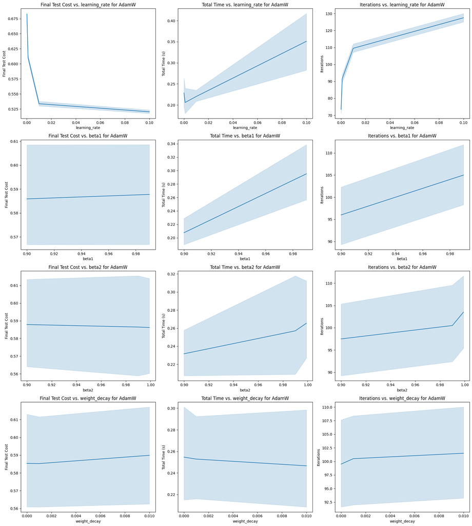

```python
for method_name in methods_and_params.keys():
    method_results = results_df[results_df['Method'] == method_name].copy()
    if not method_results.empty:
        print(f"\nResults for {method_name}:")
        display(method_results)

        # Extract hyperparameter names for the method
        hyperparam_names = list(methods_and_params[method_name].get('hyperparams', {}).keys())

        # Plot results for methods with only 'learning_rate' as a hyperparameter
        if hyperparam_names == ['learning_rate']:
            method_results['Learning Rate'] = method_results['Hyperparameters'].apply(
                lambda x: float([s for s in x.split(', ') if 'learning_rate=' in s][0].split('=')[1]) if 'learning_rate' in x else None
            )
            method_results['Final Test Cost'] = method_results['Final Test Cost'].astype(float)

            # Set up a 1-row, 3-column grid for the plots
            fig, axes = plt.subplots(1, 3, figsize=(18, 5))
            sns.lineplot(data=method_results, x='Learning Rate', y='Final Test Cost', ax=axes[0])
            axes[0].set_title(f'Final Test Cost vs. Learning Rate for {method_name}')

            sns.lineplot(data=method_results, x='Learning Rate', y='Total Time (s)', ax=axes[1])
            axes[1].set_title(f'Total Time vs. Learning Rate for {method_name}')

            sns.lineplot(data=method_results, x='Learning Rate', y='Iterations', ax=axes[2])
            axes[2].set_title(f'Iterations vs. Learning Rate for {method_name}')

            plt.tight_layout()
            plt.show()

        # Plot results for methods with multiple hyperparameters
        elif len(hyperparam_names) > 1:
            num_rows = len(hyperparam_names)
            fig, axes = plt.subplots(num_rows, 3, figsize=(18, 5 * num_rows))  # 3 columns for each metric

            # Loop through each hyperparameter
            for i, param in enumerate(hyperparam_names):
                method_results[param] = method_results['Hyperparameters'].apply(
                    lambda x: float([s for s in x.split(', ') if f"{param}=" in s][0].split('=')[1]) if param in x else None
                )

                # Plot Final Test Cost, Total Time, and Iterations vs. the current hyperparameter
                sns.lineplot(data=method_results, x=param, y='Final Test Cost', ax=axes[i, 0])
                axes[i, 0].set_title(f'Final Test Cost vs. {param} for {method_name}')

                sns.lineplot(data=method_results, x=param, y='Total Time (s)', ax=axes[i, 1])
                axes[i, 1].set_title(f'Total Time vs. {param} for {method_name}')

                sns.lineplot(data=method_results, x=param, y='Iterations', ax=axes[i, 2])
                axes[i, 2].set_title(f'Iterations vs. {param} for {method_name}')

            plt.tight_layout()
            plt.show()

        else:
            print(f"{method_name} does not have hyperparameters to tune. Skipping plot.")
```